# PCA y SMCCA-GS aplicado sobre una cohorte ómica de pacientes con cáncer de mama

JLA

2024-04-27

# 1 Introducción

En este fichero vamos a aplicar dos técnicas de reducción de la dimensionalidad a cuatro conjuntos de datos sobre pacientes con cáncer de mama. Estos conjuntos de datos son: `DigPathology`, nos da detalles sobre el análisis digital de la imagen del tumor; `mutational_signatures`, describe detalles sobre el sistema inmune de las pacientes; `RNAseq_rawcounts`, proporciona cuantificación de genes relevantes para el estudio sin normalizar; y `Main`, contiene los datos de un análisis clásico de tumores en el que se pueden encontrar variables relacionadas con la paciente, con su sistema inmunológico, el tumor y con el entorno del mismo, entre otros.

Las dos técnicas que vamos a utilizar son la técnica clásica PCA y SMCCA_GS, una variante de CCA (canonical correlation analysis) denominada “Sparse Multiple Canonical Correlation Analysis”, que permite aplicar CCA a varios conjuntos de datos y que, además, incluye la aplicación de la técnica de ortogonalización de Gramm-Schmidt para mejorar la ortogonalidad entre las variables canónicas.

El objetivo que perseguimos es comprobar si SMCCA_GS devuelve mejores resultados que PCA. Para ello, vamos a aplicar ambas técnicas a los conjuntos de datos `DigPathology`, `mutational_signatures` y `RNAseq_rawcounts` y compararemos los resultados obtenidos. Tendremos además en cuenta como variable de clase al predictor `resp.pCR` del conjunto de datos `Main`, el cual nos indica si la paciente en cuestión ha respondido satisfactoriamente al tratamiento.

# 2 Preparación de los datos

Para comenzar, vamos a preparar los datos para poder aplicar las técnicas mentadas. Algunos de los tratamientos que vamos a hacer son eliminar las columnas que solamente contengan ceros, pues la función desarrollada en R para poder aplicar SMCCA_GS lo requiere, y reducir los conjuntos de datos a las pacientes comunes.

Empezamos cargando las librerías que vamos a utilizar, así como la función para aplicar SMCCA_GS y otra función desarrollada por nosotros y que usaremos más abajo:

```r
library(lattice)
library(ggplot2)
library(reshape2)
library(caret)
library(gridExtra)
library(fpc)
library(plyr)
library(Rmisc)

# Función para aplicar SMCCA_GS
source("function_SMCCA-GS_SSMCCA.R")
# Función desarrollada por nosotros
source("function_calcular_distancias.R")
```

Cargamos todos los conjuntos de datos:

```r
DigPathology = read.table("DigPathology.tsv", sep="\t", header=TRUE, row.names=NULL)

mutational_signatures <-read.table("mutational-signatures.tsv", sep="\t", header=TRUE, row.names=NULL)
mainFile = read.table("main.csv", sep=",", header=T, na.strings = "")

# Cargamos los datos de "RNAseq-rawcounts.tsv" intercambiando las filas por las columnas. Además, establecemos como cabeceras (nombres de las columnas) el código de los ARN e indicamos que cada columna tiene atributos enteros
RNAseq_rawcounts = read.table("RNAseq-rawcounts.tsv", sep="\t", header=TRUE, row.names=NULL)
RNAseq_rawcounts = as.data.frame(t(RNAseq_rawcounts))
names(RNAseq_rawcounts) <- RNAseq_rawcounts[1,]
RNAseq_rawcounts <- RNAseq_rawcounts[-1,]
X <- rownames(RNAseq_rawcounts)
RNAseq_rawcounts <- as.data.frame(sapply(RNAseq_rawcounts, as.integer))
RNAseq_rawcounts <- cbind(X, RNAseq_rawcounts)
```

Seleccionamos todos los identificadores:

```r
id.Mutations <- mutational_signatures$X
id.RNAs <- RNAseq_rawcounts$X
id.Main <- mainFile$Trial.ID
id.DigPat <- DigPathology$Trial.ID
```

Intersecamos los identificadores:

```r
ids <- intersect(id.Mutations, id.Main)
ids <- intersect(ids, id.RNAs)
ids <- intersect(ids, id.DigPat)
```

Eliminamos de cada conjunto de datos las filas que no se correspondan con los identificadores anteriores y eliminamos la columna con los identificadores:

```r
mutational_signatures.prep <- mutational_signatures[mutational_signatures$X %in% ids, ]
RNAseq_rawcounts.prep <- RNAseq_rawcounts[RNAseq_rawcounts$X %in% ids, ]
mainFile.prep <- mainFile[mainFile$Trial.ID %in% ids, ]
DigPathology.prep <- DigPathology[DigPathology$Trial.ID %in% ids, ]

mutational_signatures.prep$X <- NULL
RNAseq_rawcounts.prep$X <- NULL
mainFile.prep$Trial.ID <- NULL
DigPathology.prep$Trial.ID <- NULL

# Eliminamos un par de "outliers"
mutational_signatures.prep <- mutational_signatures.prep[-c(40,133), ]
RNAseq_rawcounts.prep <- RNAseq_rawcounts.prep[-c(40,133), ]
mainFile.prep <- mainFile.prep[-c(40,133), ]
DigPathology.prep <- DigPathology.prep[-c(40,133), ]
```

Comprobamos si hay valores “NA”:

```r
sum(is.na(mutational_signatures.prep))
```

```
## [1] 0
```

```r
sum(is.na(RNAseq_rawcounts.prep))
```

```
## [1] 0
```

```r
sum(is.na(mainFile.prep))
```

```
## [1] 0
```

```r
sum(is.na(DigPathology.prep))
```

```
## [1] 0
```

Seleccionamos las columnas con ceros de los conjuntos de datos:

```r
columnasCeros.mutational_signatures.prep = which(colSums(mutational_signatures.prep==0) == nrow(mutational_signatures.prep))
columnasCeros.RNAseq_rawcounts.prep = which(colSums(RNAseq_rawcounts.prep==0) == nrow(RNAseq_rawcounts.prep))
```

Eliminamos de `mutational_signatures.prep` y de `RNAseq_rawcounts.prep` las columnas con solo ceros

```r
mutational_signatures.prep.NoCeros = mutational_signatures.prep[, !(names(mutational_signatures.prep) %in% names(columnasCeros.mutational_signatures.prep))]
RNAseq_rawcounts.prep.NoCeros = RNAseq_rawcounts.prep[, !(names(RNAseq_rawcounts.prep) %in% names(columnasCeros.RNAseq_rawcounts.prep))]
```

```r
RNAseq_rawcounts.prep.NoCeros <- RNAseq_rawcounts.prep.NoCeros[, names(which(colSums(RNAseq_rawcounts.prep.NoCeros > 14) > 0.8*nrow(RNAseq_rawcounts.prep.NoCeros)))]
ncol(RNAseq_rawcounts.prep.NoCeros)
```

```
## [1] 17034
```

Ya tenemos todos los conjuntos de datos. A continuación, vamos a aplicar la técnica PCA a los conjuntos de datos `DigPathology.prep` `mutational_signatures.prep.NoCeros` y `RNAseq_rawcounts.prep.NoCeros`

# 3 PCA

Una vez realizado el preprocesado de los datos, procedemos a aplicar PCA sobre cada uno de los conjuntos de datos.

## 3.1 PCA sobre `DigPathology`

Comprobamos si tenemos algún predictor categórico:

```r
str(DigPathology.prep)
```

```
## 'data.frame':    141 obs. of  7 variables:
##  $ n_total                  : int  225937 205031 189418 132349 119075 121201 136940 62504 172122 133792 ...
##  $ fraction_cancer          : num  0.61 0.38 0.36 0.5 0.6 0.47 0.49 0.19 0.32 0.32 ...
##  $ fraction_lymph           : num  0.11 0.18 0.28 0.21 0.16 0.12 0.19 0.23 0.19 0.11 ...
##  $ fraction_stromal         : num  0.28 0.44 0.36 0.3 0.24 0.41 0.32 0.58 0.49 0.57 ...
##  $ median_cancer_KDE_knn_50 : num  -2.97 -3.08 -3.08 -3.04 -2.94 ...
##  $ median_lymph_KDE_knn_50  : num  -3.8 -3.45 -3.22 -3.35 -3.66 ...
##  $ median_stromal_KDE_knn_50: num  -3.41 -3.34 -3.24 -3.39 -3.54 ...
```

Como no hay ninguno, podemos aplicar directamente la técnica PCA:

```r
pca_result_DigPathology <- prcomp(DigPathology.prep, scale = TRUE, rank=6)
```

Podemos ver la desviación estándar de cada componente principal.

```r
pca_result_DigPathology$sdev
```

```
## [1] 2.03088325 1.12347301 0.96588020 0.68935873 0.35495702 0.28060433 0.02117415
```

La varianza explicada por cada componente principal se obtiene mediante la cuadratura de estos valores:

```r
(VE_DigPathology <- pca_result_DigPathology$sdev^2)
```

```
## [1] 4.1244867602 1.2621916054 0.9329245539 0.4752154647 0.1259944827
## [6] 0.0787387882 0.0004483448
```

```r
PVE_DigPathology <- VE_DigPathology / sum(VE_DigPathology)
round(PVE_DigPathology, 2)
```

```
## [1] 0.59 0.18 0.13 0.07 0.02 0.01 0.00
```

En la primera componente se explica el 59% de la variabilidad, mientras que en la segunda el 18%. Entre las dos primeras componentes se explica un 77% de la variabilidad. Esto lo podemos visualizar en las siguientes gráficas:

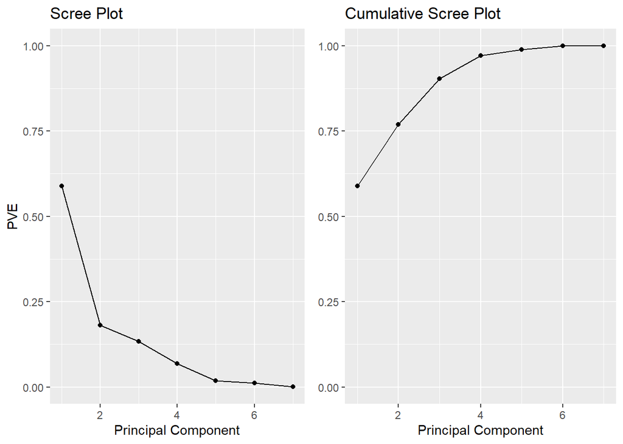

```r
# Gráfico PVE_DigPathology
PVEplot_DigPathology <- qplot(c(1:7), PVE_DigPathology) +
  geom_line() +
  xlab("Principal Component") +
  ylab("PVE") +
  ggtitle("Scree Plot") +
  ylim(0, 1)
# PVE acumulado
cumPVE_DigPathology <- qplot(c(1:7), cumsum(PVE_DigPathology)) +
  geom_line() +
  xlab("Principal Component") +
  ylab(NULL) +
  ggtitle("Cumulative Scree Plot") +
  ylim(0,1)

grid.arrange(PVEplot_DigPathology, cumPVE_DigPathology, ncol = 2)
```

Dibujamos las dos primeras componentes principales y coloreamos según el valor de la variable de clase `resp.PCR`:

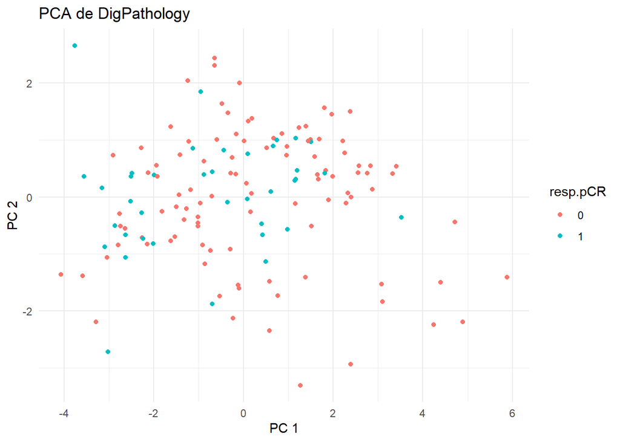

```r
data_pcas_plot_DigPathology = as.data.frame(cbind(PC1 = pca_result_DigPathology$x[, 1], PC2 = pca_result_DigPathology$x[, 2]))
data_pcas_plot_DigPathology$resp.pCR = mainFile.prep$resp.pCR

# Gráfico de componentes principales para el PCA de DigPathology usando resp.pCR
p1_DigPathology = ggplot(data = data_pcas_plot_DigPathology) + geom_point(aes(x = PC1, y = PC2, col = as.factor(resp.pCR),)) + theme_minimal()+ labs(x = "PC 1", y = "PC 2", color = "resp.pCR", title = "PCA de DigPathology")

p1_DigPathology
```

## 3.2 PCA sobre `mutational_signatures`

Comprobamos si tenemos algún predictor categórico:

```r
str(mutational_signatures.prep.NoCeros)
```

```
## 'data.frame':    141 obs. of  23 variables:
##  $ Signature.1            : num  0.813 0.339 0.586 0.53 0.466 ...
##  $ Signature.2            : num  0 0 0 0 0 0 0 0 0 0 ...
##  $ Signature.3            : num  0 0.349 0.103 0.223 0.286 ...
##  $ Signature.4            : num  0 0 0 0 0 0 0 0 0 0 ...
##  $ Signature.5            : num  0 0 0 0 0 0 0 0 0 0 ...
##  $ Signature.6            : num  0 0 0 0 0 0 0 0 0 0 ...
##  $ Signature.7            : num  0 0 0 0 0 ...
##  $ Signature.9            : num  0 0 0 0 0 0 0 0 0 0 ...
##  $ Signature.10           : num  0 0 0 0 0 0 0 0 0 0 ...
##  $ Signature.12           : num  0 0 0 0 0 0 0 0 0 0 ...
##  $ Signature.13           : num  0 0 0 0 0 ...
##  $ Signature.15           : num  0.0821 0 0 0 0.1631 ...
##  $ Signature.16           : num  0 0 0 0 0 ...
##  $ Signature.18           : num  0 0 0 0 0 0 0 0 0 0 ...
##  $ Signature.20           : num  0 0 0 0 0 0 0 0 0 0 ...
##  $ Signature.21           : num  0 0 0.124 0 0 ...
##  $ Signature.24           : num  0 0.141 0 0.117 0 ...
##  $ Signature.25           : num  0 0 0 0 0 0 0 0 0 0 ...
##  $ Signature.26           : num  0 0 0 0 0 0 0 0 0 0 ...
##  $ Signature.27           : num  0 0 0 0 0 0 0 0 0 0 ...
##  $ Signature.29           : num  0 0 0 0 0 ...
##  $ Unknown                : num  0.1048 0.171 0.1863 0.1303 0.0842 ...
##  $ NumberMutationsAnalysed: int  158 129 98 110 108 21 23 23 304 96 ...
```

Como no hay ninguno, podemos aplicar directamente la técnica PCA:

```r
pca_result_mutational_signatures <- prcomp(mutational_signatures.prep.NoCeros, scale = TRUE, rank=6)
```

Podemos ver la desviación estándar de cada componente principal.

```r
pca_result_mutational_signatures$sdev
```

```
##  [1] 1.696124e+00 1.646480e+00 1.434976e+00 1.256199e+00 1.201982e+00
##  [6] 1.126385e+00 1.109281e+00 1.054668e+00 1.047447e+00 1.011499e+00
## [11] 9.999327e-01 9.442714e-01 9.145561e-01 8.953518e-01 7.966401e-01
## [16] 7.100515e-01 6.688097e-01 6.555329e-01 6.222711e-01 5.733045e-01
## [21] 4.498527e-01 3.671250e-01 1.230899e-15
```

La varianza explicada por cada componente principal se obtiene mediante la cuadratura de estos valores:

```r
(VE_mutational_signatures <- pca_result_mutational_signatures$sdev^2)
```

```
##  [1] 2.876835e+00 2.710898e+00 2.059156e+00 1.578035e+00 1.444761e+00
##  [6] 1.268743e+00 1.230504e+00 1.112324e+00 1.097145e+00 1.023131e+00
## [11] 9.998654e-01 8.916484e-01 8.364129e-01 8.016548e-01 6.346355e-01
## [16] 5.041731e-01 4.473064e-01 4.297234e-01 3.872213e-01 3.286781e-01
## [21] 2.023674e-01 1.347808e-01 1.515112e-30
```

```r
PVE_mutational_signatures <- VE_mutational_signatures / sum(VE_mutational_signatures)
round(PVE_mutational_signatures, 2)
```

```
##  [1] 0.13 0.12 0.09 0.07 0.06 0.06 0.05 0.05 0.05 0.04 0.04 0.04 0.04 0.03 0.03
## [16] 0.02 0.02 0.02 0.02 0.01 0.01 0.01 0.00
```

En las siguientes gráficas podemos visualizar las varianzas explicadas por cada componente principal y la varianza acumulada:

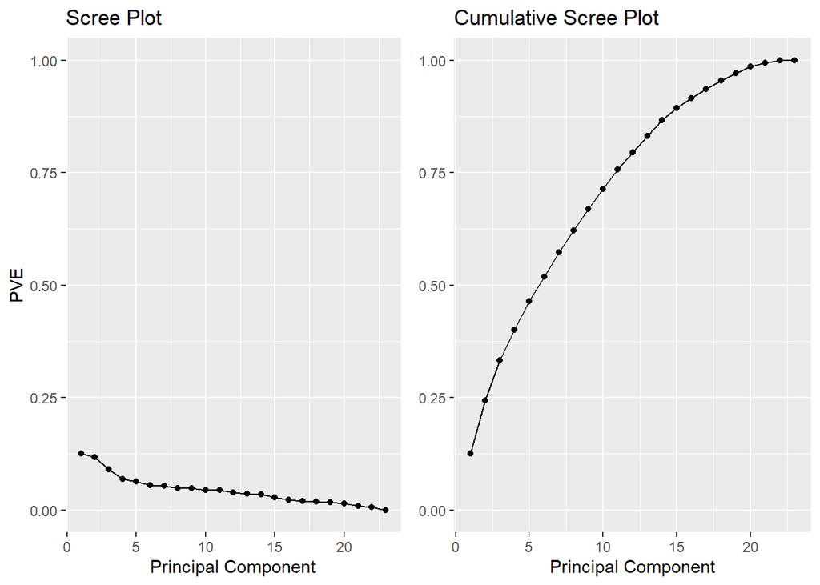

```r
# Gráfico PVE_mutational_signatures
PVEplot_mutational_signatures <- qplot(c(1:23), PVE_mutational_signatures) +
  geom_line() +
  xlab("Principal Component") +
  ylab("PVE") +
  ggtitle("Scree Plot") +
  ylim(0, 1)

# PVE acumulado
cumPVE_mutational_signatures <- qplot(c(1:23), cumsum(PVE_mutational_signatures)) +
  geom_line() +
  xlab("Principal Component") +
  ylab(NULL) +
  ggtitle("Cumulative Scree Plot") +
  ylim(0,1)

grid.arrange(PVEplot_mutational_signatures, cumPVE_mutational_signatures, ncol = 2)
```

Dibujamos los puntos coloreados según la variable de clase:

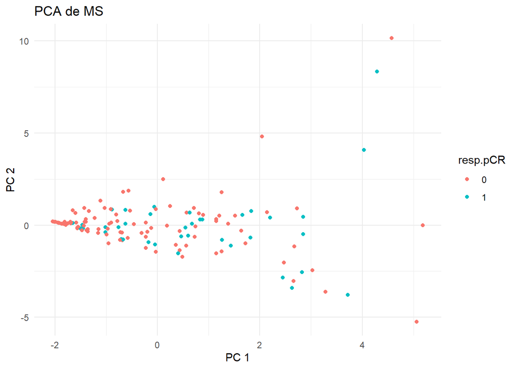

```r
data_pcas_plot_mutational_signatures = as.data.frame(cbind(PC1 = pca_result_mutational_signatures$x[, 1], PC2 = pca_result_mutational_signatures$x[, 2]))
data_pcas_plot_mutational_signatures$resp.pCR = mainFile.prep$resp.pCR

# Eliminamos los dos puntos con valores fuera de rango
#data_pcas_plot_mutational_signatures <- data_pcas_plot_mutational_signatures[-c(40,133), ]

# Gráfico de componentes principales para el PCA de mutational_signatures usando resp.pCR
p1_mutational_signatures = ggplot(data = data_pcas_plot_mutational_signatures) + geom_point(aes(x = PC1, y = PC2, col = as.factor(resp.pCR),)) + theme_minimal()+ labs(x = "PC 1", y = "PC 2", color = "resp.pCR", title = "PCA de MS")

p1_mutational_signatures
```

## 3.3 PCA sobre `RNAseq_rawcounts`

Comprobamos si tenemos algún predictor categórico:

```r
which(sapply(colnames(RNAseq_rawcounts.prep.NoCeros), function(x) class(RNAseq_rawcounts.prep.NoCeros[[x]]) != "integer") == TRUE)
```

```
## named integer(0)
```

Como no hay ninguno, podemos aplicar directamente la técnica PCA:

```r
pca_result_RNAseq_rawcounts <- prcomp(RNAseq_rawcounts.prep.NoCeros, scale = TRUE, rank=6)
```

Podemos ver la desviación estándar de cada componente principal.

```r
pca_result_RNAseq_rawcounts$sdev
```

```
##   [1] 5.067836e+01 3.453226e+01 3.258341e+01 2.908886e+01 2.508830e+01
##   [6] 2.248861e+01 2.147630e+01 1.883572e+01 1.787284e+01 1.674972e+01
##  [11] 1.591810e+01 1.511076e+01 1.445730e+01 1.413242e+01 1.351297e+01
##  [16] 1.326121e+01 1.314999e+01 1.301251e+01 1.277906e+01 1.264534e+01
##  [21] 1.251961e+01 1.231600e+01 1.223634e+01 1.170334e+01 1.144869e+01
##  [26] 1.122298e+01 1.113322e+01 1.108378e+01 1.095386e+01 1.069343e+01
##  [31] 1.063799e+01 1.053312e+01 1.045798e+01 1.030779e+01 1.021390e+01
##  [36] 1.010346e+01 9.960918e+00 9.894454e+00 9.811405e+00 9.768015e+00
##  [41] 9.679725e+00 9.667199e+00 9.548714e+00 9.336311e+00 9.277389e+00
##  [46] 9.227644e+00 9.146465e+00 9.058518e+00 8.981656e+00 8.907399e+00
##  [51] 8.833851e+00 8.792590e+00 8.700041e+00 8.640385e+00 8.566779e+00
##  [56] 8.527757e+00 8.404854e+00 8.355875e+00 8.270359e+00 8.184171e+00
##  [61] 8.146832e+00 8.055362e+00 8.014075e+00 7.931577e+00 7.844027e+00
##  [66] 7.784006e+00 7.773749e+00 7.607102e+00 7.558992e+00 7.519164e+00
##  [71] 7.475206e+00 7.425257e+00 7.371221e+00 7.313605e+00 7.276523e+00
##  [76] 7.193148e+00 7.115076e+00 7.069813e+00 7.031696e+00 6.961030e+00
##  [81] 6.920638e+00 6.850788e+00 6.786216e+00 6.755172e+00 6.683173e+00
##  [86] 6.675386e+00 6.604867e+00 6.588980e+00 6.495036e+00 6.483068e+00
##  [91] 6.447965e+00 6.331867e+00 6.299489e+00 6.272536e+00 6.196371e+00
##  [96] 6.144805e+00 6.117846e+00 6.071279e+00 6.017221e+00 5.971742e+00
## [101] 5.930573e+00 5.877412e+00 5.802461e+00 5.779852e+00 5.751577e+00
## [106] 5.691662e+00 5.664991e+00 5.637750e+00 5.568208e+00 5.538707e+00
## [111] 5.492011e+00 5.442139e+00 5.291039e+00 5.254959e+00 5.210005e+00
## [116] 5.199557e+00 5.144807e+00 5.116346e+00 5.046847e+00 5.001359e+00
## [121] 4.944861e+00 4.878653e+00 4.803239e+00 4.753753e+00 4.718219e+00
## [126] 4.687461e+00 4.653584e+00 4.587733e+00 4.583526e+00 4.543840e+00
## [131] 4.358880e+00 4.299163e+00 4.268088e+00 4.182778e+00 4.156614e+00
## [136] 3.913187e+00 3.717187e+00 3.481265e+00 3.363520e+00 3.307085e+00
## [141] 4.013432e-14
```

La varianza explicada por cada componente principal se obtiene mediante la cuadratura de estos valores:

```r
(VE_RNAseq_rawcounts <- pca_result_RNAseq_rawcounts$sdev^2)
```

```
##   [1] 2.568296e+03 1.192477e+03 1.061678e+03 8.461618e+02 6.294226e+02
##   [6] 5.057375e+02 4.612314e+02 3.547842e+02 3.194385e+02 2.805530e+02
##  [11] 2.533859e+02 2.283351e+02 2.090135e+02 1.997252e+02 1.826004e+02
##  [16] 1.758596e+02 1.729222e+02 1.693255e+02 1.633044e+02 1.599046e+02
##  [21] 1.567405e+02 1.516839e+02 1.497280e+02 1.369683e+02 1.310724e+02
##  [26] 1.259552e+02 1.239486e+02 1.228501e+02 1.199871e+02 1.143494e+02
##  [31] 1.131668e+02 1.109467e+02 1.093694e+02 1.062505e+02 1.043238e+02
##  [36] 1.020798e+02 9.921989e+01 9.790022e+01 9.626366e+01 9.541413e+01
##  [41] 9.369707e+01 9.345473e+01 9.117795e+01 8.716670e+01 8.606995e+01
##  [46] 8.514941e+01 8.365782e+01 8.205675e+01 8.067015e+01 7.934176e+01
##  [51] 7.803693e+01 7.730964e+01 7.569072e+01 7.465626e+01 7.338970e+01
##  [56] 7.272264e+01 7.064156e+01 6.982065e+01 6.839884e+01 6.698066e+01
##  [61] 6.637088e+01 6.488885e+01 6.422540e+01 6.290991e+01 6.152876e+01
##  [66] 6.059075e+01 6.043117e+01 5.786799e+01 5.713836e+01 5.653783e+01
##  [71] 5.587870e+01 5.513444e+01 5.433490e+01 5.348881e+01 5.294779e+01
##  [76] 5.174138e+01 5.062431e+01 4.998226e+01 4.944475e+01 4.845594e+01
##  [81] 4.789524e+01 4.693330e+01 4.605273e+01 4.563235e+01 4.466480e+01
##  [86] 4.456078e+01 4.362427e+01 4.341466e+01 4.218549e+01 4.203018e+01
##  [91] 4.157625e+01 4.009253e+01 3.968357e+01 3.934471e+01 3.839502e+01
##  [96] 3.775863e+01 3.742804e+01 3.686043e+01 3.620695e+01 3.566170e+01
## [101] 3.517169e+01 3.454398e+01 3.366855e+01 3.340669e+01 3.308063e+01
## [106] 3.239501e+01 3.209213e+01 3.178423e+01 3.100494e+01 3.067727e+01
## [111] 3.016218e+01 2.961688e+01 2.799509e+01 2.761460e+01 2.714415e+01
## [116] 2.703539e+01 2.646904e+01 2.617700e+01 2.547066e+01 2.501359e+01
## [121] 2.445165e+01 2.380126e+01 2.307110e+01 2.259817e+01 2.226159e+01
## [126] 2.197229e+01 2.165584e+01 2.104730e+01 2.100871e+01 2.064648e+01
## [131] 1.899984e+01 1.848281e+01 1.821657e+01 1.749563e+01 1.727744e+01
## [136] 1.531303e+01 1.381748e+01 1.211920e+01 1.131326e+01 1.093681e+01
## [141] 1.610764e-27
```

```r
PVE_RNAseq_rawcounts <- VE_RNAseq_rawcounts / sum(VE_RNAseq_rawcounts)
round(PVE_RNAseq_rawcounts, 2)
```

```
##   [1] 0.15 0.07 0.06 0.05 0.04 0.03 0.03 0.02 0.02 0.02 0.01 0.01 0.01 0.01 0.01
##  [16] 0.01 0.01 0.01 0.01 0.01 0.01 0.01 0.01 0.01 0.01 0.01 0.01 0.01 0.01 0.01
##  [31] 0.01 0.01 0.01 0.01 0.01 0.01 0.01 0.01 0.01 0.01 0.01 0.01 0.01 0.01 0.01
##  [46] 0.00 0.00 0.00 0.00 0.00 0.00 0.00 0.00 0.00 0.00 0.00 0.00 0.00 0.00 0.00
##  [61] 0.00 0.00 0.00 0.00 0.00 0.00 0.00 0.00 0.00 0.00 0.00 0.00 0.00 0.00 0.00
##  [76] 0.00 0.00 0.00 0.00 0.00 0.00 0.00 0.00 0.00 0.00 0.00 0.00 0.00 0.00 0.00
##  [91] 0.00 0.00 0.00 0.00 0.00 0.00 0.00 0.00 0.00 0.00 0.00 0.00 0.00 0.00 0.00
## [106] 0.00 0.00 0.00 0.00 0.00 0.00 0.00 0.00 0.00 0.00 0.00 0.00 0.00 0.00 0.00
## [121] 0.00 0.00 0.00 0.00 0.00 0.00 0.00 0.00 0.00 0.00 0.00 0.00 0.00 0.00 0.00
## [136] 0.00 0.00 0.00 0.00 0.00 0.00
```

En las siguientes gráficas podemos visualizar las varianzas explicadas por cada componente principal y la varianza acumulada:

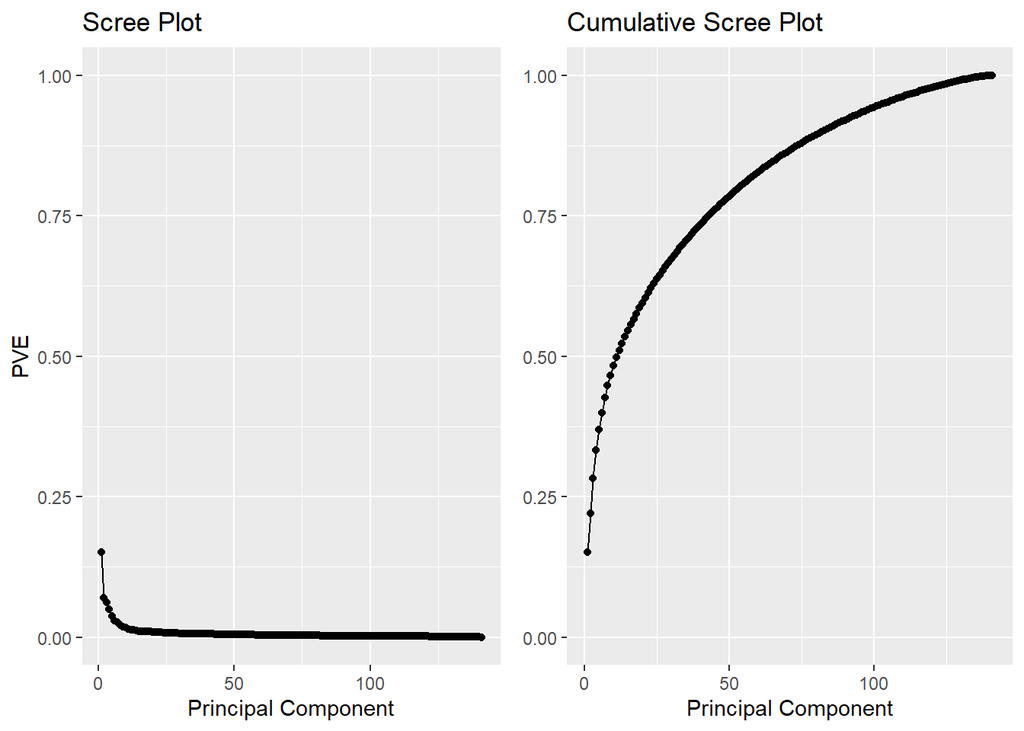

```r
# Gráfico PVE_RNAseq_rawcounts
PVEplot_RNAseq_rawcounts <- qplot(c(1:141), PVE_RNAseq_rawcounts) +
  geom_line() +
  xlab("Principal Component") +
  ylab("PVE") +
  ggtitle("Scree Plot") +
  ylim(0, 1)

# PVE acumulado
cumPVE_RNAseq_rawcounts <- qplot(c(1:141), cumsum(PVE_RNAseq_rawcounts)) +
  geom_line() +
  xlab("Principal Component") +
  ylab(NULL) +
  ggtitle("Cumulative Scree Plot") +
  ylim(0,1)

grid.arrange(PVEplot_RNAseq_rawcounts, cumPVE_RNAseq_rawcounts, ncol = 2)
```

Dibujamos los datos y los coloreamos según la variable de clase `resp.pCR`:

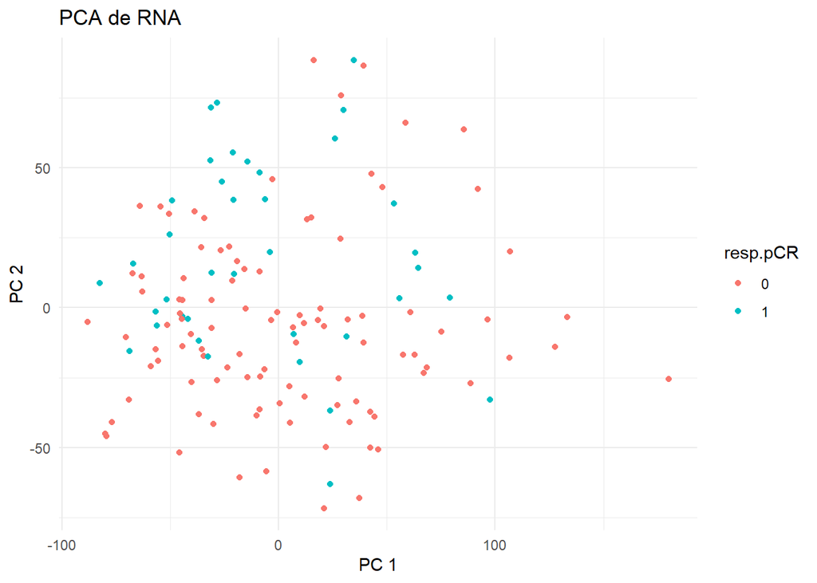

```r
data_pcas_plot_RNAseq_rawcounts = as.data.frame(cbind(PC1 = pca_result_RNAseq_rawcounts$x[, 1], PC2 = pca_result_RNAseq_rawcounts$x[, 2]))
data_pcas_plot_RNAseq_rawcounts$resp.pCR = mainFile.prep$resp.pCR

# Gráfico de componentes principales para el PCA de RNAseq_rawcounts usando resp.pCR
p1_RNAseq_rawcounts = ggplot(data = data_pcas_plot_RNAseq_rawcounts) + geom_point(aes(x = PC1, y = PC2, col = as.factor(resp.pCR),)) + theme_minimal()+ labs(x = "PC 1", y = "PC 2", color = "resp.pCR", title = "PCA de RNA")

p1_RNAseq_rawcounts
```

## 3.4 Correlaciones

Calculamos las matrices de correlación entre cada par de conjuntos de datos:

```r
# Calculamos las matrices de correlación
cor_DP_MS = cor(pca_result_DigPathology$x, pca_result_mutational_signatures$x)
cor_DP_RNA = cor(pca_result_DigPathology$x, pca_result_RNAseq_rawcounts$x)
cor_MS_RNA = cor(pca_result_mutational_signatures$x, pca_result_RNAseq_rawcounts$x)
```

## 3.5 Aplicamos bosques aleatorios

Para finalizar con los datos de PCA, introducimos los tres PCAs en un único conjunto de datos y aplicamos la técnica de aprendizaje computacional `bosques aleatorios`.

Combinamos los tres conjuntos de datos resultantes de la aplicación de los PCAs:

```r
# Combinamos los tres conjuntos de datos resultantes de la aplicación de los PCAs
pca_result_total = cbind(pca_result_DigPathology$x, pca_result_mutational_signatures$x, pca_result_RNAseq_rawcounts$x)

# Cambiamos el nombre de las columnas
colnames(pca_result_total) <- c("PC_DP_1", "PC_DP_2", "PC_DP_3", "PC_DP_4", "PC_DP_5", "PC_DP_6", "PC_MS_1", "PC_MS_2", "PC_MS_3", "PC_MS_4", "PC_MS_5", "PC_MS_6", "PC_RNA_1", "PC_RNA_2", "PC_RNA_3", "PC_RNA_4", "PC_RNA_5", "PC_RNA_6")

# Añadimos la variable de clase `resp.pCR`
pca_result_total = cbind(pca_result_total, mainFile.prep$resp.pCR)

# Lo establecemos como `data.frame`
pca_result_total = as.data.frame(pca_result_total)

# Le cambiamos el nombre a la columna `resp.pCR` para que se llame `resp.pCR`
colnames(pca_result_total)[19] = c("resp.pCR")

# Indicamos que la variable de clase `resp.pCR` es de tipo `factor`
pca_result_total$resp.pCR = as.factor(pca_result_total$resp.pCR)
```

Dividimos los datos para poder hacer el entrenamiento:

```r
pca_result_total.Var.Salida.Usada = c("resp.pCR")
pca_result_total.Var.Entrada.Usadas = setdiff(names(pca_result_total), pca_result_total.Var.Salida.Usada)

pca_result_total.TrainIdx.80 <- createDataPartition(pca_result_total[[pca_result_total.Var.Salida.Usada]],
                                   p = 0.8,
                                   list = FALSE,
                                   times = 1)

pca_result_total.Train <- pca_result_total[pca_result_total.TrainIdx.80,]
pca_result_total.Test <- pca_result_total[-pca_result_total.TrainIdx.80,]
```

Creamos un grid de hiperparámetros con los siguientes datos para poder ver cuál de estas combinaciones es la mejor. Introducimos valores 8 y 12 para `mtry`, este valor no puede crecer mucho más debido a que tenemos 18 variables en nuestro conjunto de datos; `gini` y `extratrees` para `splitrule`, para ver cuál de todas estas reglas funciona mejor; y a `min.node.size` le asignamos los valores 5, 10 y 15, así podremos ver en los resultados si el algoritmo nos pide mayor o menor potencia.

```r
mygrid = expand.grid(mtry = c(8,12),
                     splitrule=c("gini","extratrees"),
                     min.node.size  =c(5,10,15))
print(mygrid)
```

```
##    mtry  splitrule min.node.size
## 1     8       gini             5
## 2    12       gini             5
## 3     8 extratrees             5
## 4    12 extratrees             5
## 5     8       gini            10
## 6    12       gini            10
## 7     8 extratrees            10
## 8    12 extratrees            10
## 9     8       gini            15
## 10   12       gini            15
## 11    8 extratrees            15
## 12   12 extratrees            15
```

```r
fitControl <- trainControl(## 5-fold CV
                           method = "repeatedcv",
                           number = 3,
                           repeats = 50)
```

```r
rangerFit <- train(pca_result_total.Train[pca_result_total.Var.Entrada.Usadas],
                 pca_result_total.Train[[pca_result_total.Var.Salida.Usada]],
                 method = "ranger",
                 trControl = fitControl,
                 tuneGrid = mygrid,
                 num.trees = 15,
                 importance='impurity')

# Guardamos los resultados
saveRDS(rangerFit, file = "bosquesAleatorios_PCA_1.rds")
```

Leemos los datos y los imprimimos por pantalla:

```r
rangerFit <- readRDS(file = "bosquesAleatorios_PCA_1.rds")
rangerFit
```

[output not shown]

Realizamos la predicción del conjunto de entrenamiento:

```r
pred.train <- predict(rangerFit, pca_result_total.Train[pca_result_total.Var.Entrada.Usadas])
confusionMatrix(data = pred.train, reference = pca_result_total.Train[[pca_result_total.Var.Salida.Usada]])
```

```
## Confusion Matrix and Statistics
##
##           Reference
## Prediction  0  1
##          0 82 21
##          1  1 10
##
##                Accuracy : 0.807
##                  95% CI : (0.7225, 0.8749)
##     No Information Rate : 0.7281
##     P-Value [Acc > NIR] : 0.03351
##
##                   Kappa : 0.3892
##
##  Mcnemar's Test P-Value : 5.104e-05
##
##             Sensitivity : 0.9880
##             Specificity : 0.3226
##          Pos Pred Value : 0.7961
##          Neg Pred Value : 0.9091
##              Prevalence : 0.7281
##          Detection Rate : 0.7193
##    Detection Prevalence : 0.9035
##       Balanced Accuracy : 0.6553
##
##        'Positive' Class : 0
##
```

Realizamos la predicción del conjunto de validación:

```r
pred.test_PCA <- predict(rangerFit, pca_result_total.Test[pca_result_total.Var.Entrada.Usadas])
confusionMatrix(data = pred.test_PCA, reference = pca_result_total.Test[[pca_result_total.Var.Salida.Usada]])
```

```
## Confusion Matrix and Statistics
##
##           Reference
## Prediction  0  1
##          0 20  6
##          1  0  1
##
##                Accuracy : 0.7778
##                  95% CI : (0.5774, 0.9138)
##     No Information Rate : 0.7407
##     P-Value [Acc > NIR] : 0.42690
##
##                   Kappa : 0.198
##
##  Mcnemar's Test P-Value : 0.04123
##
##             Sensitivity : 1.0000
##             Specificity : 0.1429
##          Pos Pred Value : 0.7692
##          Neg Pred Value : 1.0000
##              Prevalence : 0.7407
##          Detection Rate : 0.7407
##    Detection Prevalence : 0.9630
##       Balanced Accuracy : 0.5714
##
##        'Positive' Class : 0
##
```

# 4 SMCCA-GS

Procedemos ahora a aplicar SMCCA-GS a los tres conjuntos de datos:

## 4.1 SMCCA_GS sobre DigPathology, mutational_signatures, RNAseq_rawcounts

Aplicamos `SMCCA-GS` sobre los conjuntos de datos `DigPathology`, `mutational_signatures` y `RNAseq_rawcounts` utilizando seis variables canónicas:

```r
moData = list(DigPathology.prep, mutational_signatures.prep.NoCeros, RNAseq_rawcounts.prep.NoCeros)
ncomponentes=6
opt_num = "full"
SMCCA_GS_out = MultiCCA_GS(moData, ncomponents=ncomponentes, opt_num = opt_num)
saveRDS(SMCCA_GS_out, file = "SMCCA_GS_out_DP_MS_RNA_17k.rds")
```

Leemos los resultados obtenidos tras aplicar SMCCA_GS:

```r
SMCCA_GS_out_DP_MS_RNA <- readRDS("SMCCA_GS_out_DP_MS_RNA_17k.rds")
print(names(SMCCA_GS_out_DP_MS_RNA))
```

```
## [1] "canon_var" "weight"    "penalty"
```

Antes de dibujar los puntos vamos a ver brevemente si hemos aplicado correctamente la técnica SMCCA_GS:

```r
cv_x1_DP_MS_RNA = SMCCA_GS_out_DP_MS_RNA$canon_var[[1]]
cv_x2_DP_MS_RNA = SMCCA_GS_out_DP_MS_RNA$canon_var[[2]]
cv_x3_DP_MS_RNA = SMCCA_GS_out_DP_MS_RNA$canon_var[[3]]
print(sprintf("The dimension of CV X1 is %d x %d.", dim(cv_x1_DP_MS_RNA)[1], dim(cv_x1_DP_MS_RNA)[2]))
```

```
## [1] "The dimension of CV X1 is 141 x 6."
```

```r
print(sprintf("The dimension of CV X2 is %d x %d.", dim(cv_x2_DP_MS_RNA)[1], dim(cv_x2_DP_MS_RNA)[2]))
```

```
## [1] "The dimension of CV X2 is 141 x 6."
```

```r
print(sprintf("The dimension of CV X3 is %d x %d.", dim(cv_x3_DP_MS_RNA)[1], dim(cv_x3_DP_MS_RNA)[2]))
```

```
## [1] "The dimension of CV X3 is 141 x 6."
```

```r
cv_w1_DP_MS_RNA = SMCCA_GS_out_DP_MS_RNA$weight[[1]]
cv_w2_DP_MS_RNA = SMCCA_GS_out_DP_MS_RNA$weight[[2]]
cv_w3_DP_MS_RNA = SMCCA_GS_out_DP_MS_RNA$weight[[3]]
print(sprintf("The dimension of weight X1 is %d x %d.", dim(cv_w1_DP_MS_RNA)[1], dim(cv_w1_DP_MS_RNA)[2]))
```

```
## [1] "The dimension of weight X1 is 7 x 6."
```

```r
print(sprintf("The dimension of weight X2 is %d x %d.", dim(cv_w2_DP_MS_RNA)[1], dim(cv_w2_DP_MS_RNA)[2]))
```

```
## [1] "The dimension of weight X2 is 23 x 6."
```

```r
print(sprintf("The dimension of weight X3 is %d x %d.", dim(cv_w3_DP_MS_RNA)[1], dim(cv_w3_DP_MS_RNA)[2]))
```

```
## [1] "The dimension of weight X3 is 17034 x 6."
```

Las matrices de pesos también tienen las dimensiones esperadas. Las filas se corresponden con los predictores de cada conjunto de datos y las columnas con las variables canónicas (VC por sus siglas en español). Estas matrices nos indican el peso que tiene cada predictor en cada VC.

## 4.2 Comparativa entre las variables canónicas obtenidas

Veamos si SMCCA_GS ha tenido en cuenta los distintos conjuntos de datos para calcular las variables canónicas de cada método:

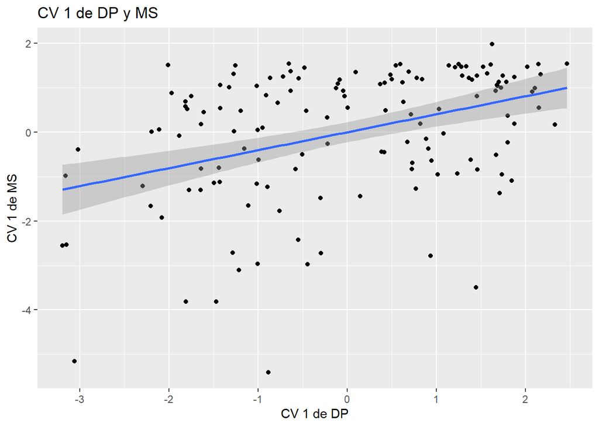

```r
data_SMCCA_GS_DP_MS = as.data.frame(cbind(CV1_DP = cv_x1_DP_MS_RNA[, 1], CV1_MS = cv_x2_DP_MS_RNA[, 1]))
ggplot(data = data_SMCCA_GS_DP_MS) + geom_point(aes(x = CV1_DP, y = CV1_MS)) + geom_smooth(method = "lm", aes(x = CV1_DP, y = CV1_MS)) + labs(x = "CV 1 de DP", y = "CV 1 de MS", title = "CV 1 de DP y MS")
```

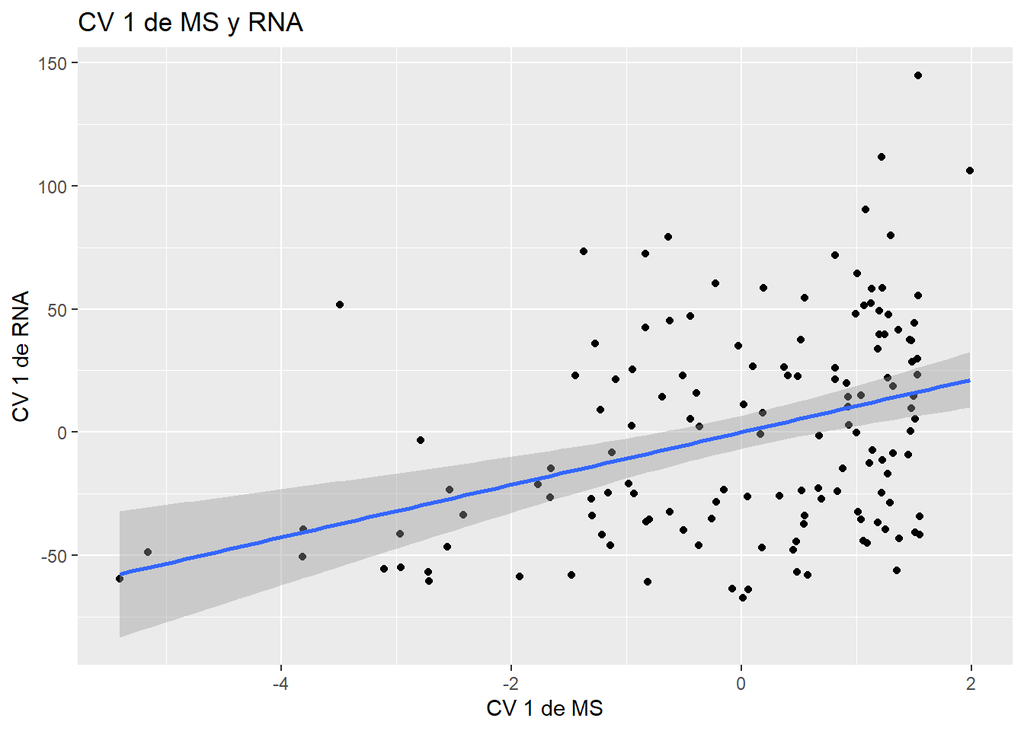

```r
data_SMCCA_GS_MS_RNA = as.data.frame(cbind(CV1_MS = cv_x2_DP_MS_RNA[, 1], CV1_RNA = cv_x3_DP_MS_RNA[, 1]))
ggplot(data = data_SMCCA_GS_MS_RNA) + geom_point(aes(x = CV1_MS, y = CV1_RNA)) + geom_smooth(method = "lm", aes(x = CV1_MS, y = CV1_RNA)) + labs(x = "CV 1 de MS", y = "CV 1 de RNA", title = "CV 1 de MS y RNA")
```

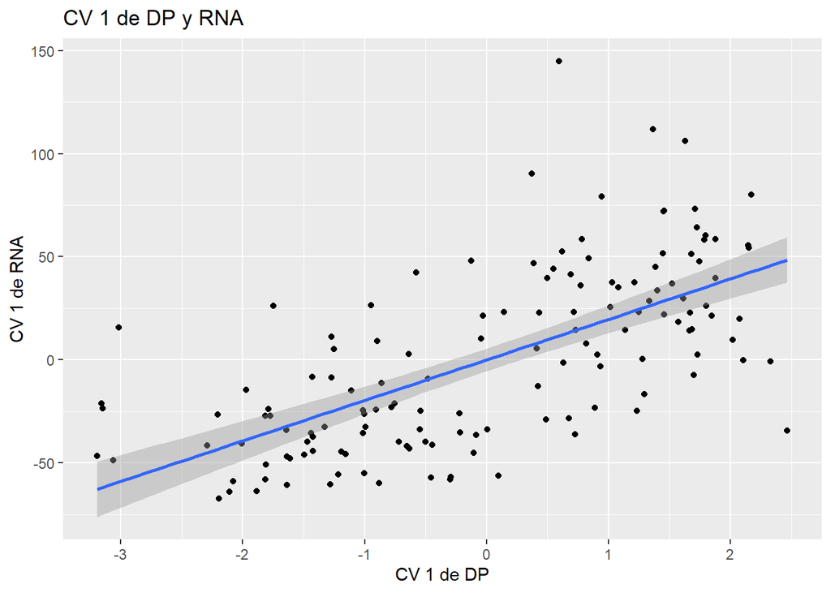

```r
data_SMCCA_GS_DP_RNA = as.data.frame(cbind(CV1_DP = cv_x1_DP_MS_RNA[, 1], CV1_RNA = cv_x3_DP_MS_RNA[, 1]))
ggplot(data = data_SMCCA_GS_DP_RNA) + geom_point(aes(x = CV1_DP, y = CV1_RNA)) + geom_smooth(method = "lm", aes(x = CV1_DP, y = CV1_RNA)) + labs(x = "CV 1 de DP", y = "CV 1 de RNA", title = "CV 1 de DP y RNA")
```

Estos gráficos tienen, para cada par de conjuntos de datos, en el eje “X” la primera variable canónica de uno de los conjuntos de datos y en el eje “Y” la primera variable canónica de otro de los conjuntos de datos. Con estas gráficas, pretendemos visualizar si las variables canónicas obtenidas entre los distintos conjuntos de datos están correlacionadas entre sí, pues queremos comprobar una de las principales ventajas de SMCCA-GS, y es que tiene en cuenta todos los conjuntos de datos para calcular las variables canónicas.

En estas imágenes podemos ver que, en general, parece que los tres pares de variables canónicas están correlacionadas entre sí. Veamos si est correlación es significativa. Para ello, vamos a comprobar si el p-valor del test de correlación es significativo:

```r
# Calculamos el test de correlación
cor_test_DP_MS <- cor.test(data_SMCCA_GS_DP_MS$CV1_DP, data_SMCCA_GS_DP_MS$CV1_MS)
cor_test_MS_RNA <- cor.test(data_SMCCA_GS_MS_RNA$CV1_MS, data_SMCCA_GS_MS_RNA$CV1_RNA)
cor_test_DP_RNA <- cor.test(data_SMCCA_GS_DP_RNA$CV1_DP, data_SMCCA_GS_DP_RNA$CV1_RNA)

# Obtenemos los p-valores
cor_test_DP_MS$p.value
```

```
## [1] 1.513683e-06
```

```r
cor_test_MS_RNA$p.value
```

```
## [1] 8.951282e-06
```

```r
cor_test_DP_RNA$p.value
```

```
## [1] 2.94208e-18
```

| Pares de conjuntos de datos | p-valor |
| --- | --- |
| DigPathology - mutational_signatures | 1.513683e-06 |
| mutational_signatures - RNAseq_rawcounts | 8.951282e-06 |
| DigPathology - RNAseq_rawcounts | 2.94208e-18 |

Efectivamente, en los tres casos observamos que el p-valor es menor que el valor de significancia (0.05), por lo que hay una correlación significativa entre ellos.

## 4.3 Representación gráfica

### 4.3.1 DigPathology

Comenzamos con el conjunto `DigPathology`:

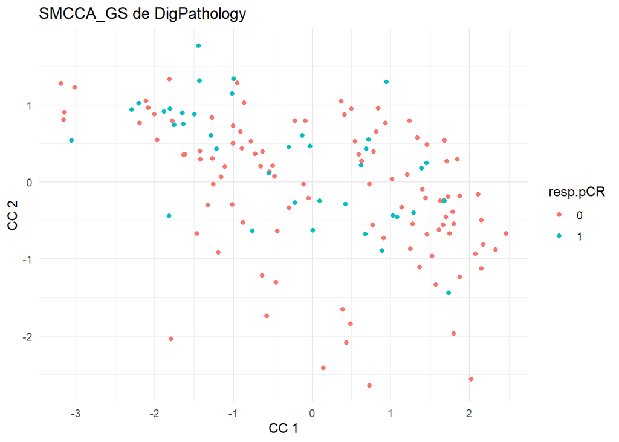

```r
data_SMCCA_GS_plot_DigPathology = as.data.frame(cbind(CC1 = cv_x1_DP_MS_RNA[, 1], CC2 = cv_x1_DP_MS_RNA[, 2]))
data_SMCCA_GS_plot_DigPathology$resp.pCR = mainFile.prep$resp.pCR

# Gráfico de las variables canónicas principales para el SMCCA_GS de DigPathology usando resp.pCR
c1_DigPathology = ggplot(data = data_SMCCA_GS_plot_DigPathology) + geom_point(aes(x = CC1, y = CC2, col = as.factor(resp.pCR),)) + theme_minimal()+ labs(x = "CC 1", y = "CC 2", color = "resp.pCR", title = "SMCCA_GS de DigPathology")

c1_DigPathology
```

### 4.3.2 mutational_signatures

Para `mutational_signatures` obtenemos lo siguiente:

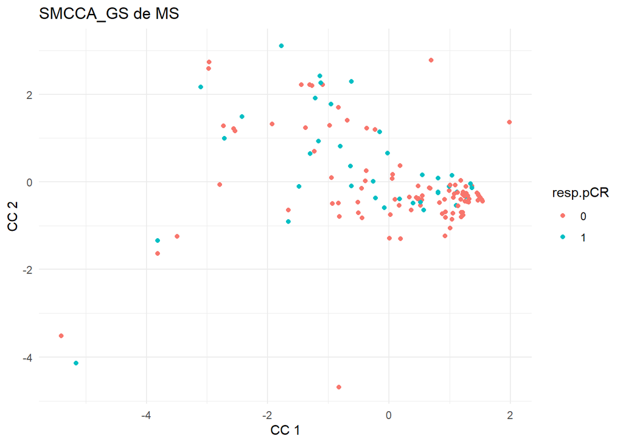

```r
data_SMCCA_GS_plot_mutational_signatures = as.data.frame(cbind(CC1 = cv_x2_DP_MS_RNA[, 1], CC2 = cv_x2_DP_MS_RNA[, 2]))
data_SMCCA_GS_plot_mutational_signatures$resp.pCR = mainFile.prep$resp.pCR

#Eliminamos los dos puntos con valores fuera de rango:
#data_SMCCA_GS_plot_mutational_signatures <- data_SMCCA_GS_plot_mutational_signatures[-c(40,133), ]

# Gráfico de las variables canónicas principales para el SMCCA_GS de mutational_signatures usando resp.pCR
c1_mutational_signatures = ggplot(data = data_SMCCA_GS_plot_mutational_signatures) + geom_point(aes(x = CC1, y = CC2, col = as.factor(resp.pCR),)) + theme_minimal()+ labs(x = "CC 1", y = "CC 2", color = "resp.pCR", title = "SMCCA_GS de MS")

c1_mutational_signatures
```

### 4.3.3 RNAseq_rawcounts

Finalizamos esta subsección con la gráfica de `RNAseq_rawcounts`:

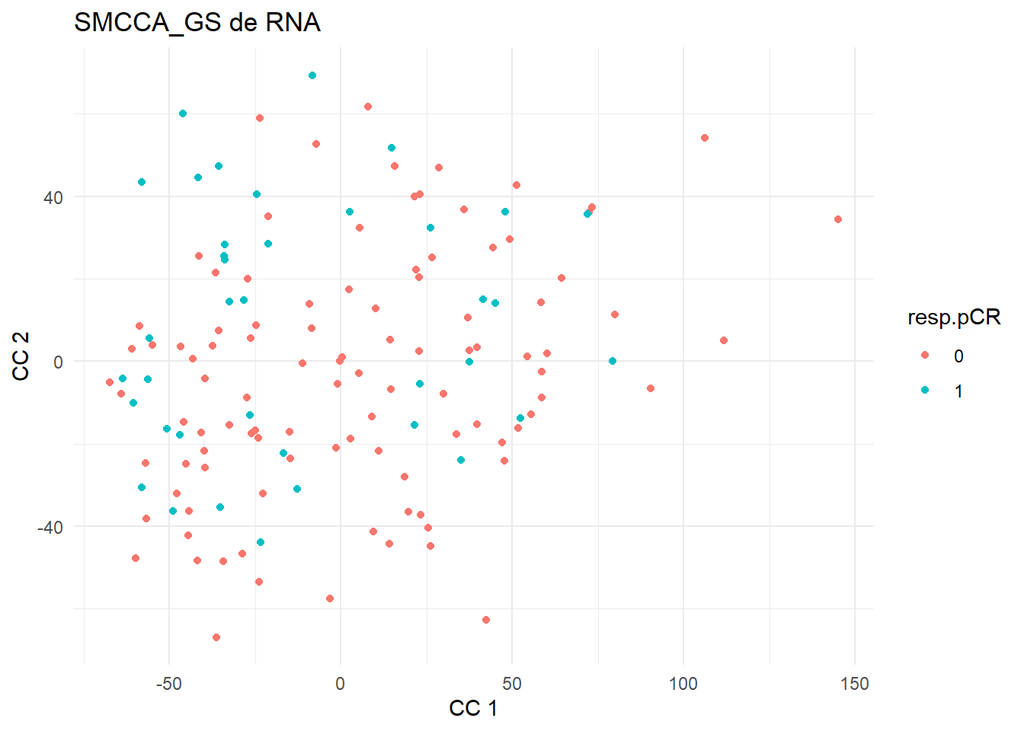

```r
data_SMCCA_GS_plot_RNAseq_rawcounts = as.data.frame(cbind(CC1 = cv_x3_DP_MS_RNA[, 1], CC2 = cv_x3_DP_MS_RNA[, 2]))
data_SMCCA_GS_plot_RNAseq_rawcounts$resp.pCR = mainFile.prep$resp.pCR

# Gráfico de las variables canónicas principales para el SMCCA_GS de RNAseq_rawcounts usando resp.pCR
c1_RNAseq_rawcounts = ggplot(data = data_SMCCA_GS_plot_RNAseq_rawcounts) + geom_point(aes(x = CC1, y = CC2, col = as.factor(resp.pCR),)) + theme_minimal()+ labs(x = "CC 1", y = "CC 2", color = "resp.pCR", title = "SMCCA_GS de RNA")

c1_RNAseq_rawcounts
```

## 4.4 Correlaciones

Calculamos las matrices de correlación entre cada par de conjuntos de datos y calculamos las diagonales de dichas matrices:

```r
# Calculamos las matrices de correlación
cor_SMCCA_GS_DP_MS = cor(cv_x1_DP_MS_RNA, cv_x2_DP_MS_RNA)
cor_SMCCA_GS_DP_RNA = cor(cv_x1_DP_MS_RNA, cv_x3_DP_MS_RNA)
cor_SMCCA_GS_MS_RNA = cor(cv_x2_DP_MS_RNA, cv_x3_DP_MS_RNA)
```

## 4.5 Aplicamos bosques aleatorios

Finalmente, vamos a aplicar la técnica de `random forests` a los conjuntos de datos resultantes. Para ello, vamos a unificarlos en un solo conjunto de datos y aplicaremos la técnica para la variable predictora `resp.pCR`.

Combinamos los tres conjuntos de datos resultantes de la aplicación de `SMCCA-GS`:

```r
# Combinamos los tres conjuntos de datos resultantes de la aplicación de `SMCCA-GS`
SMCCA_GS_total = cbind(cv_x1_DP_MS_RNA, cv_x2_DP_MS_RNA, cv_x3_DP_MS_RNA)

# Lo establecemos como `data.frame`
SMCCA_GS_total = as.data.frame(SMCCA_GS_total)

# Cambiamos el nombre de las columnas
names(SMCCA_GS_total) <- c("SMCCA_GS_DP_1", "SMCCA_GS_DP_2", "SMCCA_GS_DP_3", "SMCCA_GS_DP_4", "SMCCA_GS_DP_5", "SMCCA_GS_DP_6", "SMCCA_GS_MS_1", "SMCCA_GS_MS_2", "SMCCA_GS_MS_3", "SMCCA_GS_MS_4", "SMCCA_GS_MS_5", "SMCCA_GS_MS_6", "SMCCA_GS_RNA_1", "SMCCA_GS_RNA_2", "SMCCA_GS_RNA_3", "SMCCA_GS_RNA_4", "SMCCA_GS_RNA_5", "SMCCA_GS_RNA_6")

# Añadimos la variable de clase `resp.pCR`
SMCCA_GS_total = cbind(SMCCA_GS_total, mainFile.prep$resp.pCR)

# Le cambiamos el nombre a la columna `resp.pCR` para que se llame `resp.pCR`
names(SMCCA_GS_total)[19] = c("resp.pCR")

# Indicamos que la variable de clase `resp.pCR` es de tipo `factor`
SMCCA_GS_total$resp.pCR = as.factor(SMCCA_GS_total$resp.pCR)
```

Dividimos los datos para poder hacer el entrenamiento:

```r
SMCCA_GS_total.Var.Salida.Usada = c("resp.pCR")
SMCCA_GS_total.Var.Entrada.Usadas = setdiff(names(SMCCA_GS_total), SMCCA_GS_total.Var.Salida.Usada)

SMCCA_GS_total.TrainIdx.80 <- createDataPartition(SMCCA_GS_total[[SMCCA_GS_total.Var.Salida.Usada]],
                                   p = 0.8,
                                   list = FALSE,
                                   times = 1)

SMCCA_GS_total.Train <- SMCCA_GS_total[SMCCA_GS_total.TrainIdx.80,]
SMCCA_GS_total.Test <- SMCCA_GS_total[-SMCCA_GS_total.TrainIdx.80,]
```

Creamos un grid de hiperparámetros con los siguientes datos para poder ver cuál de estas combinaciones es la mejor. Introducimos valores 8 y 12 para `mtry`, este valor no puede crecer mucho más debido a que tenemos 18 variables en nuestro conjunto de datos; `gini` y `extratrees` para `splitrule`, para ver cuál de todas estas reglas funciona mejor; y a `min.node.size` le asignamos los valores 5, 10 y 15, así podremos ver en los resultados si el algoritmo nos pide mayor o menor potencia.

```r
mygrid = expand.grid(mtry = c(8,12),
                     splitrule=c("gini","extratrees"),
                     min.node.size  =c(5,10,15))
print(mygrid)
```

```
##    mtry  splitrule min.node.size
## 1     8       gini             5
## 2    12       gini             5
## 3     8 extratrees             5
## 4    12 extratrees             5
## 5     8       gini            10
## 6    12       gini            10
## 7     8 extratrees            10
## 8    12 extratrees            10
## 9     8       gini            15
## 10   12       gini            15
## 11    8 extratrees            15
## 12   12 extratrees            15
```

Procedemos a entrenar con este grid de hiperparámetros. Nótese que apenas hemos introducido 15 árboles dado que este algoritmo es muy potente y estimamos que con este valor vamos a obtener muy buenos resultados. En caso de no ser así, aumentaremos el número de árboles con el consiguiente aumento del coste computacional.

```r
fitControl <- trainControl(## 5-fold CV
                           method = "repeatedcv",
                           number = 3,
                           repeats = 50)
```

```r
rangerFit <- train(SMCCA_GS_total.Train[SMCCA_GS_total.Var.Entrada.Usadas],
                 SMCCA_GS_total.Train[[SMCCA_GS_total.Var.Salida.Usada]],
                 method = "ranger",
                 trControl = fitControl,
                 tuneGrid = mygrid,
                 num.trees = 15,
                 importance='impurity')

# Guardamos los resultados
saveRDS(rangerFit, file = "bosquesAleatorios_SMCCA_GS_1.rds")
```

Leemos los datos y los imprimimos por pantalla:

```r
rangerFit <- readRDS(file = "bosquesAleatorios_SMCCA_GS_1.rds")
rangerFit
```

[output not shown]

Realizamos la predicción del conjunto de entrenamiento:

```r
pred.train <- predict(rangerFit, SMCCA_GS_total.Train[SMCCA_GS_total.Var.Entrada.Usadas])
confusionMatrix(data = pred.train, reference = SMCCA_GS_total.Train[[SMCCA_GS_total.Var.Salida.Usada]])
```

```
## Confusion Matrix and Statistics
##
##           Reference
## Prediction  0  1
##          0 72 27
##          1 11  4
##
##                Accuracy : 0.6667
##                  95% CI : (0.5723, 0.7522)
##     No Information Rate : 0.7281
##     P-Value [Acc > NIR] : 0.94041
##
##                   Kappa : -0.0042
##
##  Mcnemar's Test P-Value : 0.01496
##
##             Sensitivity : 0.8675
##             Specificity : 0.1290
##          Pos Pred Value : 0.7273
##          Neg Pred Value : 0.2667
##              Prevalence : 0.7281
##          Detection Rate : 0.6316
##    Detection Prevalence : 0.8684
##       Balanced Accuracy : 0.4983
##
##        'Positive' Class : 0
##
```

Realizamos la predicción del conjunto de validación:

```r
pred.test_SMCCA_GS <- predict(rangerFit, SMCCA_GS_total.Test[SMCCA_GS_total.Var.Entrada.Usadas])
confusionMatrix(data = pred.test_SMCCA_GS, reference = SMCCA_GS_total.Test[[SMCCA_GS_total.Var.Salida.Usada]])
```

```
## Confusion Matrix and Statistics
##
##           Reference
## Prediction  0  1
##          0 18  3
##          1  2  4
##
##                Accuracy : 0.8148
##                  95% CI : (0.6192, 0.937)
##     No Information Rate : 0.7407
##     P-Value [Acc > NIR] : 0.2622
##
##                   Kappa : 0.4944
##
##  Mcnemar's Test P-Value : 1.0000
##
##             Sensitivity : 0.9000
##             Specificity : 0.5714
##          Pos Pred Value : 0.8571
##          Neg Pred Value : 0.6667
##              Prevalence : 0.7407
##          Detection Rate : 0.6667
##    Detection Prevalence : 0.7778
##       Balanced Accuracy : 0.7357
##
##        'Positive' Class : 0
##
```

# 5 Distancia entre pares de puntos en el espacio de proyección

## 5.1 Discusión sobre las distancias obtenidas

En secciones anteriores hemos mostrado una gráfica para cada conjunto de datos y para cada una de las dos técnicas utilizadas (PCA y SMCCA_GS), en la que se pueden visualizar los puntos coloreados según el valor de la variable de clase `resp.pCR`. Dado que estamos tratando de estudiar qué técnica devuelve mejores resultados, vamos a calcular la distancia entre los puntos según el valor de `resp.pCR`; y para realizar el cálculo de estas distancias, hemos utilizado dos métodos: `calinhara` y `dudahart2`.

La métrica `calinhara` (índice de Calinski-Harabasz) evalúa la calidad de los grupos obtenidos basándose en la varianza entre grupos y en la varianza dentro de los grupos. Por otro lado, `dudahart2` (índice de Dunn-Hartigan) devuelve en su parámetro `dh` la proporción entre la SSW (la variabilidad dentro de cada grupo -suma de las diferencias al cuadrado entre cada observación y su media grupal-) y la SST (variación total del conjunto de datos -suma de las diferencias al cuadrado entre cada observación y al media general-).

Por lo tanto, cuanto mayor sea el valor devuelto por `calinhara`, mayor será la distancia y, por ende, mejor el clustering dado; mientras que con el parámetro `dh` de `dudahart2` sucede lo opuesto, cuanto menor sea el valor obtenido, menor será la varianza dentro de los clusters en comparación con la varianza dentro de un único cluster, por lo que, cuanto menor sea el valor, mejor será el clustering tratado.

```r
# PCA
dist_PCA_DP <- calculos_distancias(data_pcas_plot_DigPathology, data_pcas_plot_DigPathology$resp.pCR)
dist_PCA_MS <- calculos_distancias(data_pcas_plot_mutational_signatures, data_pcas_plot_mutational_signatures$resp.pCR)
dist_PCA_RNA <- calculos_distancias(data_pcas_plot_RNAseq_rawcounts, data_pcas_plot_RNAseq_rawcounts$resp.pCR)

# SMCCA-GS
dist_SMCCA_GS_DP <- calculos_distancias(data_SMCCA_GS_plot_DigPathology, data_SMCCA_GS_plot_DigPathology$resp.pCR)
dist_SMCCA_GS_MS <- calculos_distancias(data_SMCCA_GS_plot_mutational_signatures, data_SMCCA_GS_plot_mutational_signatures$resp.pCR)
dist_SMCCA_GS_RNA <- calculos_distancias(data_SMCCA_GS_plot_RNAseq_rawcounts, data_SMCCA_GS_plot_RNAseq_rawcounts$resp.pCR)
```

Los resultados obtenidos con `calinhara` son los siguientes:

| Dataset | PCA | SMCCA-GS |
| --- | --- | --- |
| DigPathology | 11.5304115 | 14.4636383 |
| mutational_signatures | 10.424044 | 13.669284 |
| RNAseq_rawcounts | 5.2981619 | 4.3529584 |

En la siguiente tabla se muestran los resultados obtenidos con el método `dudahart2`. En este caso nos hemos fijado en el parámetro `$dh`.

| Dataset | PCA | SMCCA-GS |
| --- | --- | --- |
| DigPathology | 0.9234014 | 0.905752 |
| mutational_signatures | 0.9302385 | 0.9104647 |
| RNAseq_rawcounts | 0.9632832 | 0.9696347 |

De acuerdo con el método `calinhara`, `SMCCA_GS` realiza una mejor separación de los puntos en los conjuntos de datos `DigPathology` y `mutational_signatures`. Sin embargo, para el conjunto de datos `RNAseq_rawcounts`, la separación de los puntos es mayor, y por tanto mejor, con PCA.

Asimismo, `dudahart2` devuelve un restulado similar, notando lógicamente que las diferencias no son tan altas por estar los valores de `dh` normalizados entre 0 y 1.

## 5.2 Aplicamos bootstrapping

Para ahondar en el estudio de las distancias de los puntos y ver qué técnica realiza un mejor agrupamiento de los datos, vamos a aplicar la técnica “bootstrapping”. Para ello, vamos a tomar, de cada conjunto de datos, con repetición de todos los valores . Esto lo vamos a realizar diez veces:

```r
resample <- createResample(data_pcas_plot_mutational_signatures[[pca_result_total.Var.Salida.Usada]],
                                   list = TRUE,
                                   times = 10)
```

Creamos los conjuntos de datos con los remuestreos que acabamos de hacer:

```r
# Creamos los conjuntos de datos de PCA
data_pcas_plot_DigPathology.resample_1 <- data_pcas_plot_DigPathology[resample[[1]], ]
data_pcas_plot_DigPathology.resample_2 <- data_pcas_plot_DigPathology[resample[[2]], ]
data_pcas_plot_DigPathology.resample_3 <- data_pcas_plot_DigPathology[resample[[3]], ]
data_pcas_plot_DigPathology.resample_4 <- data_pcas_plot_DigPathology[resample[[4]], ]
data_pcas_plot_DigPathology.resample_5 <- data_pcas_plot_DigPathology[resample[[5]], ]
data_pcas_plot_DigPathology.resample_6 <- data_pcas_plot_DigPathology[resample[[6]], ]
data_pcas_plot_DigPathology.resample_7 <- data_pcas_plot_DigPathology[resample[[7]], ]
data_pcas_plot_DigPathology.resample_8 <- data_pcas_plot_DigPathology[resample[[8]], ]
data_pcas_plot_DigPathology.resample_9 <- data_pcas_plot_DigPathology[resample[[9]], ]
data_pcas_plot_DigPathology.resample_10 <- data_pcas_plot_DigPathology[resample[[10]], ]

data_pcas_plot_mutational_signatures.resample_1 <- data_pcas_plot_mutational_signatures[resample[[1]], ]
data_pcas_plot_mutational_signatures.resample_2 <- data_pcas_plot_mutational_signatures[resample[[2]], ]
data_pcas_plot_mutational_signatures.resample_3 <- data_pcas_plot_mutational_signatures[resample[[3]], ]
data_pcas_plot_mutational_signatures.resample_4 <- data_pcas_plot_mutational_signatures[resample[[4]], ]
data_pcas_plot_mutational_signatures.resample_5 <- data_pcas_plot_mutational_signatures[resample[[5]], ]
data_pcas_plot_mutational_signatures.resample_6 <- data_pcas_plot_mutational_signatures[resample[[6]], ]
data_pcas_plot_mutational_signatures.resample_7 <- data_pcas_plot_mutational_signatures[resample[[7]], ]
data_pcas_plot_mutational_signatures.resample_8 <- data_pcas_plot_mutational_signatures[resample[[8]], ]
data_pcas_plot_mutational_signatures.resample_9 <- data_pcas_plot_mutational_signatures[resample[[9]], ]
data_pcas_plot_mutational_signatures.resample_10 <- data_pcas_plot_mutational_signatures[resample[[10]], ]

data_pcas_plot_RNAseq_rawcounts.resample_1 <- data_pcas_plot_RNAseq_rawcounts[resample[[1]], ]
data_pcas_plot_RNAseq_rawcounts.resample_2 <- data_pcas_plot_RNAseq_rawcounts[resample[[2]], ]
data_pcas_plot_RNAseq_rawcounts.resample_3 <- data_pcas_plot_RNAseq_rawcounts[resample[[3]], ]
data_pcas_plot_RNAseq_rawcounts.resample_4 <- data_pcas_plot_RNAseq_rawcounts[resample[[4]], ]
data_pcas_plot_RNAseq_rawcounts.resample_5 <- data_pcas_plot_RNAseq_rawcounts[resample[[5]], ]
data_pcas_plot_RNAseq_rawcounts.resample_6 <- data_pcas_plot_RNAseq_rawcounts[resample[[6]], ]
data_pcas_plot_RNAseq_rawcounts.resample_7 <- data_pcas_plot_RNAseq_rawcounts[resample[[7]], ]
data_pcas_plot_RNAseq_rawcounts.resample_8 <- data_pcas_plot_RNAseq_rawcounts[resample[[8]], ]
data_pcas_plot_RNAseq_rawcounts.resample_9 <- data_pcas_plot_RNAseq_rawcounts[resample[[9]], ]
data_pcas_plot_RNAseq_rawcounts.resample_10 <- data_pcas_plot_RNAseq_rawcounts[resample[[10]], ]

# Creamos los conjuntos de datos de SMCCA_GS
data_SMCCA_GS_plot_DigPathology.resample_1 <- data_SMCCA_GS_plot_DigPathology[resample[[1]], ]
data_SMCCA_GS_plot_DigPathology.resample_2 <- data_SMCCA_GS_plot_DigPathology[resample[[2]], ]
data_SMCCA_GS_plot_DigPathology.resample_3 <- data_SMCCA_GS_plot_DigPathology[resample[[3]], ]
data_SMCCA_GS_plot_DigPathology.resample_4 <- data_SMCCA_GS_plot_DigPathology[resample[[4]], ]
data_SMCCA_GS_plot_DigPathology.resample_5 <- data_SMCCA_GS_plot_DigPathology[resample[[5]], ]
data_SMCCA_GS_plot_DigPathology.resample_6 <- data_SMCCA_GS_plot_DigPathology[resample[[6]], ]
data_SMCCA_GS_plot_DigPathology.resample_7 <- data_SMCCA_GS_plot_DigPathology[resample[[7]], ]
data_SMCCA_GS_plot_DigPathology.resample_8 <- data_SMCCA_GS_plot_DigPathology[resample[[8]], ]
data_SMCCA_GS_plot_DigPathology.resample_9 <- data_SMCCA_GS_plot_DigPathology[resample[[9]], ]
data_SMCCA_GS_plot_DigPathology.resample_10 <- data_SMCCA_GS_plot_DigPathology[resample[[10]], ]

data_SMCCA_GS_plot_mutational_signatures.resample_1 <- data_SMCCA_GS_plot_mutational_signatures[resample[[1]], ]
data_SMCCA_GS_plot_mutational_signatures.resample_2 <- data_SMCCA_GS_plot_mutational_signatures[resample[[2]], ]
data_SMCCA_GS_plot_mutational_signatures.resample_3 <- data_SMCCA_GS_plot_mutational_signatures[resample[[3]], ]
data_SMCCA_GS_plot_mutational_signatures.resample_4 <- data_SMCCA_GS_plot_mutational_signatures[resample[[4]], ]
data_SMCCA_GS_plot_mutational_signatures.resample_5 <- data_SMCCA_GS_plot_mutational_signatures[resample[[5]], ]
data_SMCCA_GS_plot_mutational_signatures.resample_6 <- data_SMCCA_GS_plot_mutational_signatures[resample[[6]], ]
data_SMCCA_GS_plot_mutational_signatures.resample_7 <- data_SMCCA_GS_plot_mutational_signatures[resample[[7]], ]
data_SMCCA_GS_plot_mutational_signatures.resample_8 <- data_SMCCA_GS_plot_mutational_signatures[resample[[8]], ]
data_SMCCA_GS_plot_mutational_signatures.resample_9 <- data_SMCCA_GS_plot_mutational_signatures[resample[[9]], ]
data_SMCCA_GS_plot_mutational_signatures.resample_10 <- data_SMCCA_GS_plot_mutational_signatures[resample[[10]], ]

data_SMCCA_GS_plot_RNAseq_rawcounts.resample_1 <- data_SMCCA_GS_plot_RNAseq_rawcounts[resample[[1]], ]
data_SMCCA_GS_plot_RNAseq_rawcounts.resample_2 <- data_SMCCA_GS_plot_RNAseq_rawcounts[resample[[2]], ]
data_SMCCA_GS_plot_RNAseq_rawcounts.resample_3 <- data_SMCCA_GS_plot_RNAseq_rawcounts[resample[[3]], ]
data_SMCCA_GS_plot_RNAseq_rawcounts.resample_4 <- data_SMCCA_GS_plot_RNAseq_rawcounts[resample[[4]], ]
data_SMCCA_GS_plot_RNAseq_rawcounts.resample_5 <- data_SMCCA_GS_plot_RNAseq_rawcounts[resample[[5]], ]
data_SMCCA_GS_plot_RNAseq_rawcounts.resample_6 <- data_SMCCA_GS_plot_RNAseq_rawcounts[resample[[6]], ]
data_SMCCA_GS_plot_RNAseq_rawcounts.resample_7 <- data_SMCCA_GS_plot_RNAseq_rawcounts[resample[[7]], ]
data_SMCCA_GS_plot_RNAseq_rawcounts.resample_8 <- data_SMCCA_GS_plot_RNAseq_rawcounts[resample[[8]], ]
data_SMCCA_GS_plot_RNAseq_rawcounts.resample_9 <- data_SMCCA_GS_plot_RNAseq_rawcounts[resample[[9]], ]
data_SMCCA_GS_plot_RNAseq_rawcounts.resample_10 <- data_SMCCA_GS_plot_RNAseq_rawcounts[resample[[10]], ]
```

Calculamos las distancias de los remuestreos:

```r
# Calculamos las distancias de PCA
dist_PCA_DP.resample_1 <- calculos_distancias(data_pcas_plot_DigPathology.resample_1, data_pcas_plot_DigPathology.resample_1$resp.pCR)
dist_PCA_DP.resample_2 <- calculos_distancias(data_pcas_plot_DigPathology.resample_2, data_pcas_plot_DigPathology.resample_2$resp.pCR)
dist_PCA_DP.resample_3 <- calculos_distancias(data_pcas_plot_DigPathology.resample_3, data_pcas_plot_DigPathology.resample_3$resp.pCR)
dist_PCA_DP.resample_4 <- calculos_distancias(data_pcas_plot_DigPathology.resample_4, data_pcas_plot_DigPathology.resample_4$resp.pCR)
dist_PCA_DP.resample_5 <- calculos_distancias(data_pcas_plot_DigPathology.resample_5, data_pcas_plot_DigPathology.resample_5$resp.pCR)
dist_PCA_DP.resample_6 <- calculos_distancias(data_pcas_plot_DigPathology.resample_6, data_pcas_plot_DigPathology.resample_6$resp.pCR)
dist_PCA_DP.resample_7 <- calculos_distancias(data_pcas_plot_DigPathology.resample_7, data_pcas_plot_DigPathology.resample_7$resp.pCR)
dist_PCA_DP.resample_8 <- calculos_distancias(data_pcas_plot_DigPathology.resample_8, data_pcas_plot_DigPathology.resample_8$resp.pCR)
dist_PCA_DP.resample_9 <- calculos_distancias(data_pcas_plot_DigPathology.resample_9, data_pcas_plot_DigPathology.resample_9$resp.pCR)
dist_PCA_DP.resample_10 <- calculos_distancias(data_pcas_plot_DigPathology.resample_10, data_pcas_plot_DigPathology.resample_10$resp.pCR)

dist_PCA_MS.resample_1 <- calculos_distancias(data_pcas_plot_mutational_signatures.resample_1, data_pcas_plot_mutational_signatures.resample_1$resp.pCR)
dist_PCA_MS.resample_2 <- calculos_distancias(data_pcas_plot_mutational_signatures.resample_2, data_pcas_plot_mutational_signatures.resample_2$resp.pCR)
dist_PCA_MS.resample_3 <- calculos_distancias(data_pcas_plot_mutational_signatures.resample_3, data_pcas_plot_mutational_signatures.resample_3$resp.pCR)
dist_PCA_MS.resample_4 <- calculos_distancias(data_pcas_plot_mutational_signatures.resample_4, data_pcas_plot_mutational_signatures.resample_4$resp.pCR)
dist_PCA_MS.resample_5 <- calculos_distancias(data_pcas_plot_mutational_signatures.resample_5, data_pcas_plot_mutational_signatures.resample_5$resp.pCR)
dist_PCA_MS.resample_6 <- calculos_distancias(data_pcas_plot_mutational_signatures.resample_6, data_pcas_plot_mutational_signatures.resample_6$resp.pCR)
dist_PCA_MS.resample_7 <- calculos_distancias(data_pcas_plot_mutational_signatures.resample_7, data_pcas_plot_mutational_signatures.resample_7$resp.pCR)
dist_PCA_MS.resample_8 <- calculos_distancias(data_pcas_plot_mutational_signatures.resample_8, data_pcas_plot_mutational_signatures.resample_8$resp.pCR)
dist_PCA_MS.resample_9 <- calculos_distancias(data_pcas_plot_mutational_signatures.resample_9, data_pcas_plot_mutational_signatures.resample_9$resp.pCR)
dist_PCA_MS.resample_10 <- calculos_distancias(data_pcas_plot_mutational_signatures.resample_10, data_pcas_plot_mutational_signatures.resample_10$resp.pCR)

dist_PCA_RNA.resample_1 <- calculos_distancias(data_pcas_plot_RNAseq_rawcounts.resample_1, data_pcas_plot_RNAseq_rawcounts.resample_1$resp.pCR)
dist_PCA_RNA.resample_2 <- calculos_distancias(data_pcas_plot_RNAseq_rawcounts.resample_2, data_pcas_plot_RNAseq_rawcounts.resample_2$resp.pCR)
dist_PCA_RNA.resample_3 <- calculos_distancias(data_pcas_plot_RNAseq_rawcounts.resample_3, data_pcas_plot_RNAseq_rawcounts.resample_3$resp.pCR)
dist_PCA_RNA.resample_4 <- calculos_distancias(data_pcas_plot_RNAseq_rawcounts.resample_4, data_pcas_plot_RNAseq_rawcounts.resample_4$resp.pCR)
dist_PCA_RNA.resample_5 <- calculos_distancias(data_pcas_plot_RNAseq_rawcounts.resample_5, data_pcas_plot_RNAseq_rawcounts.resample_5$resp.pCR)
dist_PCA_RNA.resample_6 <- calculos_distancias(data_pcas_plot_RNAseq_rawcounts.resample_6, data_pcas_plot_RNAseq_rawcounts.resample_6$resp.pCR)
dist_PCA_RNA.resample_7 <- calculos_distancias(data_pcas_plot_RNAseq_rawcounts.resample_7, data_pcas_plot_RNAseq_rawcounts.resample_7$resp.pCR)
dist_PCA_RNA.resample_8 <- calculos_distancias(data_pcas_plot_RNAseq_rawcounts.resample_8, data_pcas_plot_RNAseq_rawcounts.resample_8$resp.pCR)
dist_PCA_RNA.resample_9 <- calculos_distancias(data_pcas_plot_RNAseq_rawcounts.resample_9, data_pcas_plot_RNAseq_rawcounts.resample_9$resp.pCR)
dist_PCA_RNA.resample_10 <- calculos_distancias(data_pcas_plot_RNAseq_rawcounts.resample_10, data_pcas_plot_RNAseq_rawcounts.resample_10$resp.pCR)

# Calculamos las distancias de SMCCA_GS
dist_SMCCA_GS_DP.resample_1 <- calculos_distancias(data_SMCCA_GS_plot_DigPathology.resample_1, data_SMCCA_GS_plot_DigPathology.resample_1$resp.pCR)
dist_SMCCA_GS_DP.resample_2 <- calculos_distancias(data_SMCCA_GS_plot_DigPathology.resample_2, data_SMCCA_GS_plot_DigPathology.resample_2$resp.pCR)
dist_SMCCA_GS_DP.resample_3 <- calculos_distancias(data_SMCCA_GS_plot_DigPathology.resample_3, data_SMCCA_GS_plot_DigPathology.resample_3$resp.pCR)
dist_SMCCA_GS_DP.resample_4 <- calculos_distancias(data_SMCCA_GS_plot_DigPathology.resample_4, data_SMCCA_GS_plot_DigPathology.resample_4$resp.pCR)
dist_SMCCA_GS_DP.resample_5 <- calculos_distancias(data_SMCCA_GS_plot_DigPathology.resample_5, data_SMCCA_GS_plot_DigPathology.resample_5$resp.pCR)
dist_SMCCA_GS_DP.resample_6 <- calculos_distancias(data_SMCCA_GS_plot_DigPathology.resample_6, data_SMCCA_GS_plot_DigPathology.resample_6$resp.pCR)
dist_SMCCA_GS_DP.resample_7 <- calculos_distancias(data_SMCCA_GS_plot_DigPathology.resample_7, data_SMCCA_GS_plot_DigPathology.resample_7$resp.pCR)
dist_SMCCA_GS_DP.resample_8 <- calculos_distancias(data_SMCCA_GS_plot_DigPathology.resample_8, data_SMCCA_GS_plot_DigPathology.resample_8$resp.pCR)
dist_SMCCA_GS_DP.resample_9 <- calculos_distancias(data_SMCCA_GS_plot_DigPathology.resample_9, data_SMCCA_GS_plot_DigPathology.resample_9$resp.pCR)
dist_SMCCA_GS_DP.resample_10 <- calculos_distancias(data_SMCCA_GS_plot_DigPathology.resample_10, data_SMCCA_GS_plot_DigPathology.resample_10$resp.pCR)

dist_SMCCA_GS_MS.resample_1 <- calculos_distancias(data_SMCCA_GS_plot_mutational_signatures.resample_1, data_SMCCA_GS_plot_mutational_signatures.resample_1$resp.pCR)
dist_SMCCA_GS_MS.resample_2 <- calculos_distancias(data_SMCCA_GS_plot_mutational_signatures.resample_2, data_SMCCA_GS_plot_mutational_signatures.resample_2$resp.pCR)
dist_SMCCA_GS_MS.resample_3 <- calculos_distancias(data_SMCCA_GS_plot_mutational_signatures.resample_3, data_SMCCA_GS_plot_mutational_signatures.resample_3$resp.pCR)
dist_SMCCA_GS_MS.resample_4 <- calculos_distancias(data_SMCCA_GS_plot_mutational_signatures.resample_4, data_SMCCA_GS_plot_mutational_signatures.resample_4$resp.pCR)
dist_SMCCA_GS_MS.resample_5 <- calculos_distancias(data_SMCCA_GS_plot_mutational_signatures.resample_5, data_SMCCA_GS_plot_mutational_signatures.resample_5$resp.pCR)
dist_SMCCA_GS_MS.resample_6 <- calculos_distancias(data_SMCCA_GS_plot_mutational_signatures.resample_6, data_SMCCA_GS_plot_mutational_signatures.resample_6$resp.pCR)
dist_SMCCA_GS_MS.resample_7 <- calculos_distancias(data_SMCCA_GS_plot_mutational_signatures.resample_7, data_SMCCA_GS_plot_mutational_signatures.resample_7$resp.pCR)
dist_SMCCA_GS_MS.resample_8 <- calculos_distancias(data_SMCCA_GS_plot_mutational_signatures.resample_8, data_SMCCA_GS_plot_mutational_signatures.resample_8$resp.pCR)
dist_SMCCA_GS_MS.resample_9 <- calculos_distancias(data_SMCCA_GS_plot_mutational_signatures.resample_9, data_SMCCA_GS_plot_mutational_signatures.resample_9$resp.pCR)
dist_SMCCA_GS_MS.resample_10 <- calculos_distancias(data_SMCCA_GS_plot_mutational_signatures.resample_10, data_SMCCA_GS_plot_mutational_signatures.resample_10$resp.pCR)

dist_SMCCA_GS_RNA.resample_1 <- calculos_distancias(data_SMCCA_GS_plot_RNAseq_rawcounts.resample_1, data_SMCCA_GS_plot_RNAseq_rawcounts.resample_1$resp.pCR)
dist_SMCCA_GS_RNA.resample_2 <- calculos_distancias(data_SMCCA_GS_plot_RNAseq_rawcounts.resample_2, data_SMCCA_GS_plot_RNAseq_rawcounts.resample_2$resp.pCR)
dist_SMCCA_GS_RNA.resample_3 <- calculos_distancias(data_SMCCA_GS_plot_RNAseq_rawcounts.resample_3, data_SMCCA_GS_plot_RNAseq_rawcounts.resample_3$resp.pCR)
dist_SMCCA_GS_RNA.resample_4 <- calculos_distancias(data_SMCCA_GS_plot_RNAseq_rawcounts.resample_4, data_SMCCA_GS_plot_RNAseq_rawcounts.resample_4$resp.pCR)
dist_SMCCA_GS_RNA.resample_5 <- calculos_distancias(data_SMCCA_GS_plot_RNAseq_rawcounts.resample_5, data_SMCCA_GS_plot_RNAseq_rawcounts.resample_5$resp.pCR)
dist_SMCCA_GS_RNA.resample_6 <- calculos_distancias(data_SMCCA_GS_plot_RNAseq_rawcounts.resample_6, data_SMCCA_GS_plot_RNAseq_rawcounts.resample_6$resp.pCR)
dist_SMCCA_GS_RNA.resample_7 <- calculos_distancias(data_SMCCA_GS_plot_RNAseq_rawcounts.resample_7, data_SMCCA_GS_plot_RNAseq_rawcounts.resample_7$resp.pCR)
dist_SMCCA_GS_RNA.resample_8 <- calculos_distancias(data_SMCCA_GS_plot_RNAseq_rawcounts.resample_8, data_SMCCA_GS_plot_RNAseq_rawcounts.resample_8$resp.pCR)
dist_SMCCA_GS_RNA.resample_9 <- calculos_distancias(data_SMCCA_GS_plot_RNAseq_rawcounts.resample_9, data_SMCCA_GS_plot_RNAseq_rawcounts.resample_9$resp.pCR)
dist_SMCCA_GS_RNA.resample_10 <- calculos_distancias(data_SMCCA_GS_plot_RNAseq_rawcounts.resample_10, data_SMCCA_GS_plot_RNAseq_rawcounts.resample_10$resp.pCR)
```

Los intervalos de confianza los vamos a hallar utilizando una función auxiliar. Para ello, primero guardamos las distancias obtenidas en vectores:

```r
# Guardamos los valores obtenidos en distintos vectores según la técnica utilizada (PCA o SMCCA_GS), el conjunto de datos y el método usado para hallar la distancia (calinhara o dudahart2)

# PCA
v_dist_PCA_DP_calinhara = c(dist_PCA_DP.resample_1[[1]], dist_PCA_DP.resample_2[[1]], dist_PCA_DP.resample_3[[1]], dist_PCA_DP.resample_4[[1]], dist_PCA_DP.resample_5[[1]], dist_PCA_DP.resample_6[[1]], dist_PCA_DP.resample_7[[1]], dist_PCA_DP.resample_8[[1]], dist_PCA_DP.resample_9[[1]], dist_PCA_DP.resample_10[[1]])

v_dist_PCA_DP_dudahart2 = c(dist_PCA_DP.resample_1[[2]]$dh, dist_PCA_DP.resample_2[[2]]$dh, dist_PCA_DP.resample_3[[2]]$dh, dist_PCA_DP.resample_4[[2]]$dh, dist_PCA_DP.resample_5[[2]]$dh, dist_PCA_DP.resample_6[[2]]$dh, dist_PCA_DP.resample_7[[2]]$dh, dist_PCA_DP.resample_8[[2]]$dh, dist_PCA_DP.resample_9[[2]]$dh, dist_PCA_DP.resample_10[[2]]$dh)

v_dist_PCA_MS_calinhara = c(dist_PCA_MS.resample_1[[1]], dist_PCA_MS.resample_2[[1]], dist_PCA_MS.resample_3[[1]], dist_PCA_MS.resample_4[[1]], dist_PCA_MS.resample_5[[1]], dist_PCA_MS.resample_6[[1]], dist_PCA_MS.resample_7[[1]], dist_PCA_MS.resample_8[[1]], dist_PCA_MS.resample_9[[1]], dist_PCA_MS.resample_10[[1]])

v_dist_PCA_MS_dudahart2 = c(dist_PCA_MS.resample_1[[2]]$dh, dist_PCA_MS.resample_2[[2]]$dh, dist_PCA_MS.resample_3[[2]]$dh, dist_PCA_MS.resample_4[[2]]$dh, dist_PCA_MS.resample_5[[2]]$dh, dist_PCA_MS.resample_6[[2]]$dh, dist_PCA_MS.resample_7[[2]]$dh, dist_PCA_MS.resample_8[[2]]$dh, dist_PCA_MS.resample_9[[2]]$dh, dist_PCA_MS.resample_10[[2]]$dh)

v_dist_PCA_RNA_calinhara = c(dist_PCA_RNA.resample_1[[1]], dist_PCA_RNA.resample_2[[1]], dist_PCA_RNA.resample_3[[1]], dist_PCA_RNA.resample_4[[1]], dist_PCA_RNA.resample_5[[1]], dist_PCA_RNA.resample_6[[1]], dist_PCA_RNA.resample_7[[1]], dist_PCA_RNA.resample_8[[1]], dist_PCA_RNA.resample_9[[1]], dist_PCA_RNA.resample_10[[1]])

v_dist_PCA_RNA_dudahart2 = c(dist_PCA_RNA.resample_1[[2]]$dh, dist_PCA_RNA.resample_2[[2]]$dh, dist_PCA_RNA.resample_3[[2]]$dh, dist_PCA_RNA.resample_4[[2]]$dh, dist_PCA_RNA.resample_5[[2]]$dh, dist_PCA_RNA.resample_6[[2]]$dh, dist_PCA_RNA.resample_7[[2]]$dh, dist_PCA_RNA.resample_8[[2]]$dh, dist_PCA_RNA.resample_9[[2]]$dh, dist_PCA_RNA.resample_10[[2]]$dh)

# SMCCA_GS
v_dist_SMCCA_GS_DP_calinhara = c(dist_SMCCA_GS_DP.resample_1[[1]], dist_SMCCA_GS_DP.resample_2[[1]], dist_SMCCA_GS_DP.resample_3[[1]], dist_SMCCA_GS_DP.resample_4[[1]], dist_SMCCA_GS_DP.resample_5[[1]], dist_SMCCA_GS_DP.resample_6[[1]], dist_SMCCA_GS_DP.resample_7[[1]], dist_SMCCA_GS_DP.resample_8[[1]], dist_SMCCA_GS_DP.resample_9[[1]], dist_SMCCA_GS_DP.resample_10[[1]])

v_dist_SMCCA_GS_DP_dudahart2 = c(dist_SMCCA_GS_DP.resample_1[[2]]$dh, dist_SMCCA_GS_DP.resample_2[[2]]$dh, dist_SMCCA_GS_DP.resample_3[[2]]$dh, dist_SMCCA_GS_DP.resample_4[[2]]$dh, dist_SMCCA_GS_DP.resample_5[[2]]$dh, dist_SMCCA_GS_DP.resample_6[[2]]$dh, dist_SMCCA_GS_DP.resample_7[[2]]$dh, dist_SMCCA_GS_DP.resample_8[[2]]$dh, dist_SMCCA_GS_DP.resample_9[[2]]$dh, dist_SMCCA_GS_DP.resample_10[[2]]$dh)

v_dist_SMCCA_GS_MS_calinhara = c(dist_SMCCA_GS_MS.resample_1[[1]], dist_SMCCA_GS_MS.resample_2[[1]], dist_SMCCA_GS_MS.resample_3[[1]], dist_SMCCA_GS_MS.resample_4[[1]], dist_SMCCA_GS_MS.resample_5[[1]], dist_SMCCA_GS_MS.resample_6[[1]], dist_SMCCA_GS_MS.resample_7[[1]], dist_SMCCA_GS_MS.resample_8[[1]], dist_SMCCA_GS_MS.resample_9[[1]], dist_SMCCA_GS_MS.resample_10[[1]])

v_dist_SMCCA_GS_MS_dudahart2 = c(dist_SMCCA_GS_MS.resample_1[[2]]$dh, dist_SMCCA_GS_MS.resample_2[[2]]$dh, dist_SMCCA_GS_MS.resample_3[[2]]$dh, dist_SMCCA_GS_MS.resample_4[[2]]$dh, dist_SMCCA_GS_MS.resample_5[[2]]$dh, dist_SMCCA_GS_MS.resample_6[[2]]$dh, dist_SMCCA_GS_MS.resample_7[[2]]$dh, dist_SMCCA_GS_MS.resample_8[[2]]$dh, dist_SMCCA_GS_MS.resample_9[[2]]$dh, dist_SMCCA_GS_MS.resample_10[[2]]$dh)

v_dist_SMCCA_GS_RNA_calinhara = c(dist_SMCCA_GS_RNA.resample_1[[1]], dist_SMCCA_GS_RNA.resample_2[[1]], dist_SMCCA_GS_RNA.resample_3[[1]], dist_SMCCA_GS_RNA.resample_4[[1]], dist_SMCCA_GS_RNA.resample_5[[1]], dist_SMCCA_GS_RNA.resample_6[[1]], dist_SMCCA_GS_RNA.resample_7[[1]], dist_SMCCA_GS_RNA.resample_8[[1]], dist_SMCCA_GS_RNA.resample_9[[1]], dist_SMCCA_GS_RNA.resample_10[[1]])

v_dist_SMCCA_GS_RNA_dudahart2 = c(dist_SMCCA_GS_RNA.resample_1[[2]]$dh, dist_SMCCA_GS_RNA.resample_2[[2]]$dh, dist_SMCCA_GS_RNA.resample_3[[2]]$dh, dist_SMCCA_GS_RNA.resample_4[[2]]$dh, dist_SMCCA_GS_RNA.resample_5[[2]]$dh, dist_SMCCA_GS_RNA.resample_6[[2]]$dh, dist_SMCCA_GS_RNA.resample_7[[2]]$dh, dist_SMCCA_GS_RNA.resample_8[[2]]$dh, dist_SMCCA_GS_RNA.resample_9[[2]]$dh, dist_SMCCA_GS_RNA.resample_10[[2]]$dh)
```

Calculamos los intervalos de confianza:

```r
# PCA
ic_PCA_DP_calinhara <- CI(v_dist_PCA_DP_calinhara)
ic_PCA_DP_dudahart2 <- CI(v_dist_PCA_DP_dudahart2)
ic_PCA_MS_calinhara <- CI(v_dist_PCA_MS_calinhara)
ic_PCA_MS_dudahart2 <- CI(v_dist_PCA_MS_dudahart2)
ic_PCA_RNA_calinhara <- CI(v_dist_PCA_RNA_calinhara)
ic_PCA_RNA_dudahart2 <- CI(v_dist_PCA_RNA_dudahart2)

# SMCCA_GS
ic_SMCCA_GS_DP_calinhara <- CI(v_dist_SMCCA_GS_DP_calinhara)
ic_SMCCA_GS_DP_dudahart2 <- CI(v_dist_SMCCA_GS_DP_dudahart2)
ic_SMCCA_GS_MS_calinhara <- CI(v_dist_SMCCA_GS_MS_calinhara)
ic_SMCCA_GS_MS_dudahart2 <- CI(v_dist_SMCCA_GS_MS_dudahart2)
ic_SMCCA_GS_RNA_calinhara <- CI(v_dist_SMCCA_GS_RNA_calinhara)
ic_SMCCA_GS_RNA_dudahart2 <- CI(v_dist_SMCCA_GS_RNA_dudahart2)
```

### 5.2.1 Resultados

En las siguientes tablas se muestra una comparativa de los intervalos de confianza obtenidos. La primera se corresponde con los valores usando el método `calinhara`, mientras que la segunda se corresponde con los de `dudahart2`:

| Dataset | PCA | SMCCA-GS |
| --- | --- | --- |
| DigPathology | (8.6779437, 13.152765) | (11.2729222, 16.1612142) |
| mutational_signatures | (8.7526181, 14.1840086) | (10.2915038, 13.8358999) |
| RNAseq_rawcounts | (4.5062337, 6.9390536) | (3.1332737, 6.2948683) |

| Dataset | PCA | SMCCA-GS |
| --- | --- | --- |
| DigPathology | (0.913948, 0.9411456) | (0.8962148, 0.9249536) |
| mutational_signatures | (0.9077135, 0.940905) | (0.9096481, 0.9310772) |
| RNAseq_rawcounts | (0.9526866, 0.9684623) | (0.9569874, 0.9778119) |

De acuerdo con estos resultados, vemos que hay ligeras modificaciones con respecto a lo visto en la sección previa. Según la métrica `calinhara`, SMCCA_GS realiza una mejor separación de los grupos con el conjunto de datos `DigPathology`, un resultado similar con `mutational_signatures`, y peor con `RNAseq_rawcounts`. Lo mismo sucede con los resultados de `dudahart2`.

# 6 Comparativa de los resultados

En esta sección vamos a hacer una breve comparativa de los resultados obtenidos para PCA y para SMCCA-GS. Comenzamos primero con una breve comparativa visual:

## 6.1 Comparativa visual

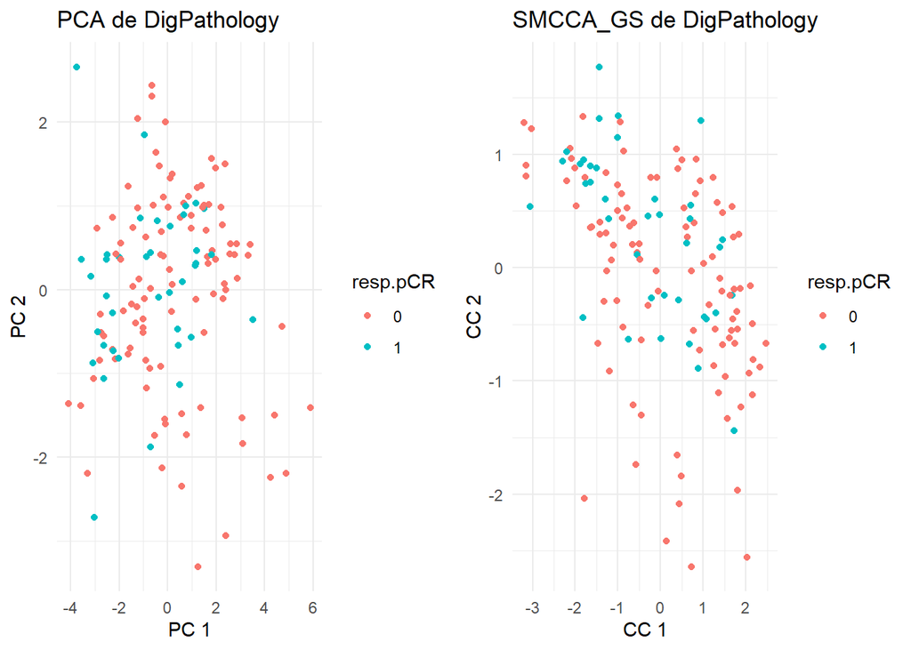

```r
grid.arrange(p1_DigPathology, c1_DigPathology, ncol = 2)
```

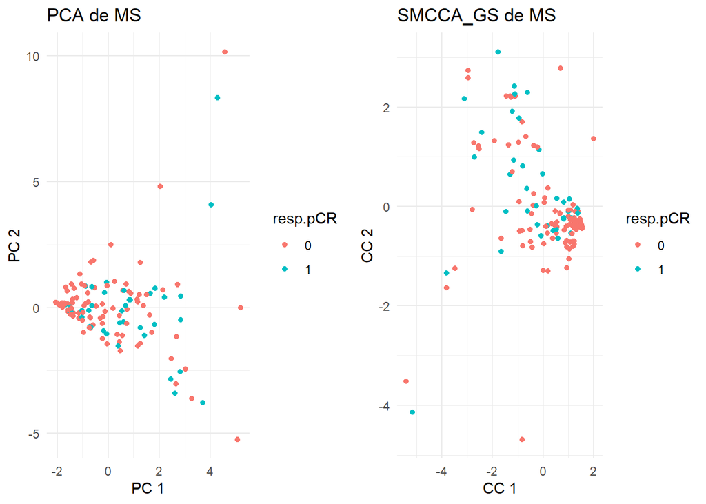

```r
grid.arrange(p1_mutational_signatures, c1_mutational_signatures, ncol = 2)
```

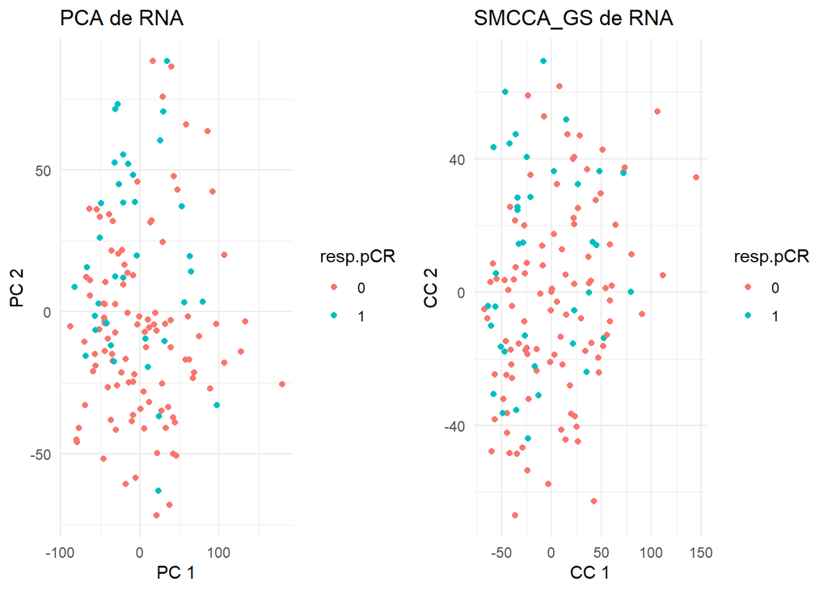

```r
grid.arrange(p1_RNAseq_rawcounts, c1_RNAseq_rawcounts, ncol = 2)
```

En estas gráficas podemos ver una comparativa entre las dos primeras componentes principales (o variables canónicas) obtenidas por cada técnica en cada conjunto de datos. En ellas, se puede apreciar que PCA y SMCCA-GS parecen compartir una cierta semejanza en la disposición de los puntos y que, en ninguno de los dos casos podemos ver, de forma visual, que alguna de las dos técnicas logre agrupar los puntos según la respuesta al tratamiento de las pacientes (variable `resp.pCR`).

## 6.2 Correlaciones entre pares de componentes generados por cada método

En las siguientes imágenes visualizamos las matrices de correlación entre cada par de conjuntos de datos realizando una comparación entre las dos ténicas utilizadas.

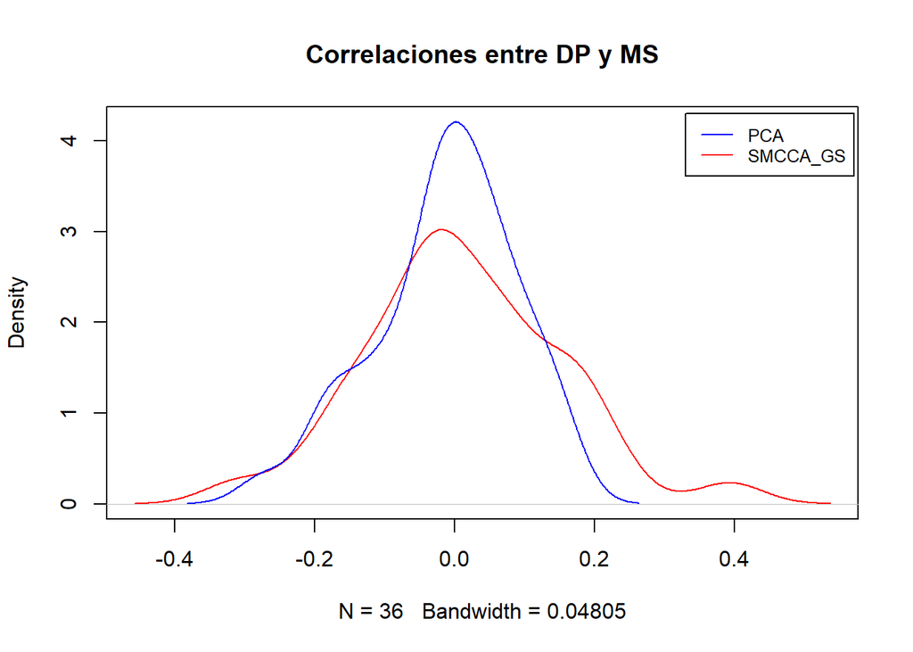

```r
# Comparamos las matrices de correlación entre los dos métodos
plot(density(cor_SMCCA_GS_DP_MS),
     ylim = range(density(cor_SMCCA_GS_DP_MS)$y, density(cor_DP_MS)$y),
     xlim = range(density(cor_SMCCA_GS_DP_MS)$x, density(cor_DP_MS)$x),
     main = "Correlaciones entre DP y MS",
     col = "red")
lines(density(cor_DP_MS), col = "blue")
legend(x=0.33, y = 4.3, legend = c("PCA", "SMCCA_GS"), col = c("blue", "red"), lty=1, cex=0.8)
```

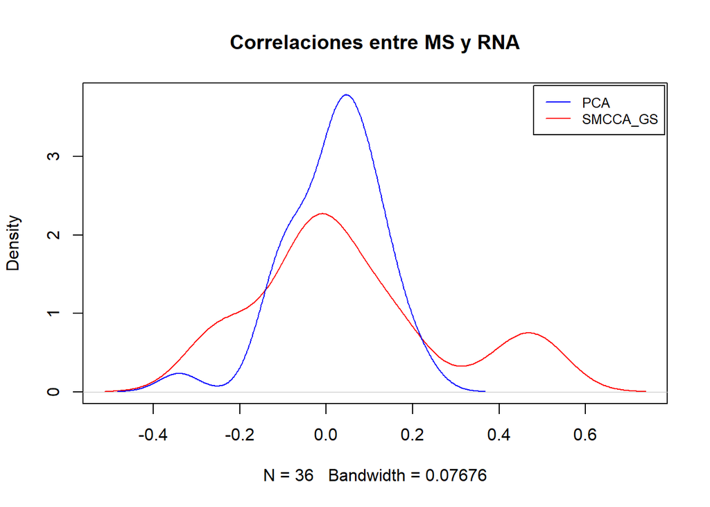

```r
plot(density(cor_SMCCA_GS_MS_RNA),
     ylim = range(density(cor_SMCCA_GS_MS_RNA)$y, density(cor_MS_RNA)$y),
     xlim = range(density(cor_SMCCA_GS_MS_RNA)$x, density(cor_MS_RNA)$x),
     main = "Correlaciones entre MS y RNA",
     col = "red")
lines(density(cor_MS_RNA), col = "blue")
legend(x=0.48, y = 3.9, legend = c("PCA", "SMCCA_GS"), col = c("blue", "red"), lty=1, cex=0.8)
```

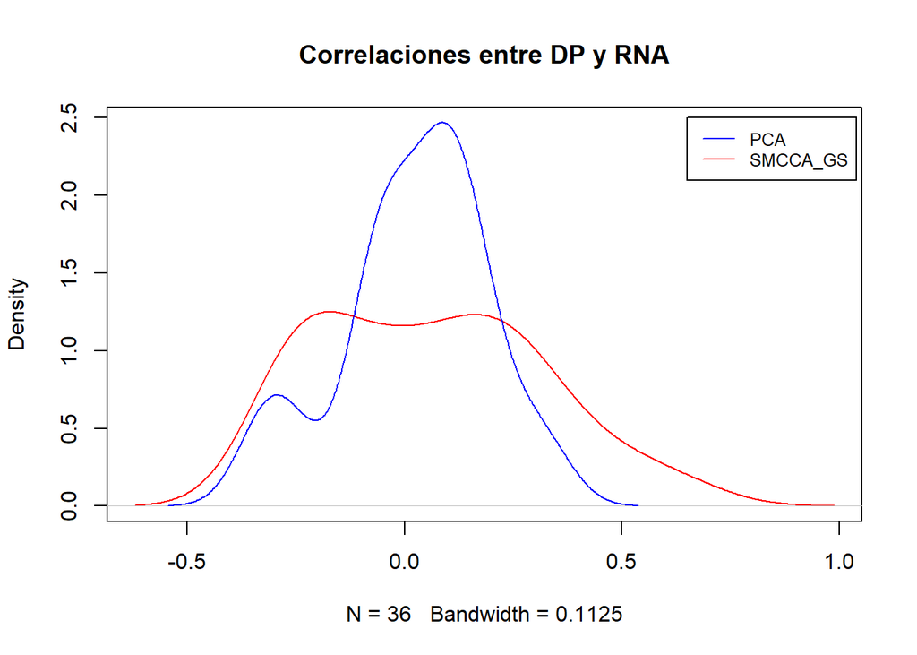

```r
plot(density(cor_SMCCA_GS_DP_RNA),
     ylim = range(density(cor_SMCCA_GS_DP_RNA)$y, density(cor_DP_RNA)$y),
     xlim = range(density(cor_SMCCA_GS_DP_RNA)$x, density(cor_DP_RNA)$x),
     main = "Correlaciones entre DP y RNA",
     col = "red")
lines(density(cor_DP_RNA), col = "blue")
legend(x=0.65, y = 2.5, legend = c("PCA", "SMCCA_GS"), col = c("blue", "red"), lty=1, cex=0.8)
```

En conjunto, estas imágenes muestran que la técnica PCA tiene una ventaja sobre SMCCA-GS en la obtención de componentes principales ortogonales entre sí.

## 6.3 Resultados de los bosques aleatorios

Para finalizar, vamos a volver a visualizar los resultados obtenidos tras la aplicación de la técnica de aprendizaje computacional “bosques aleatorios” y a hacer unos breves comentarios sobre ellos. Primero se muestran los resultados de PCA y después los de SMCCA_GS:

```r
confusionMatrix(data = pred.test_PCA, reference = pca_result_total.Test[[pca_result_total.Var.Salida.Usada]])
```

```
## Confusion Matrix and Statistics
##
##           Reference
## Prediction  0  1
##          0 20  6
##          1  0  1
##
##                Accuracy : 0.7778
##                  95% CI : (0.5774, 0.9138)
##     No Information Rate : 0.7407
##     P-Value [Acc > NIR] : 0.42690
##
##                   Kappa : 0.198
##
##  Mcnemar's Test P-Value : 0.04123
##
##             Sensitivity : 1.0000
##             Specificity : 0.1429
##          Pos Pred Value : 0.7692
##          Neg Pred Value : 1.0000
##              Prevalence : 0.7407
##          Detection Rate : 0.7407
##    Detection Prevalence : 0.9630
##       Balanced Accuracy : 0.5714
##
##        'Positive' Class : 0
##
```

```r
confusionMatrix(data = pred.test_SMCCA_GS, reference = SMCCA_GS_total.Test[[SMCCA_GS_total.Var.Salida.Usada]])
```

```
## Confusion Matrix and Statistics
##
##           Reference
## Prediction  0  1
##          0 18  3
##          1  2  4
##
##                Accuracy : 0.8148
##                  95% CI : (0.6192, 0.937)
##     No Information Rate : 0.7407
##     P-Value [Acc > NIR] : 0.2622
##
##                   Kappa : 0.4944
##
##  Mcnemar's Test P-Value : 1.0000
##
##             Sensitivity : 0.9000
##             Specificity : 0.5714
##          Pos Pred Value : 0.8571
##          Neg Pred Value : 0.6667
##              Prevalence : 0.7407
##          Detection Rate : 0.6667
##    Detection Prevalence : 0.7778
##       Balanced Accuracy : 0.7357
##
##        'Positive' Class : 0
##
```

En la siguiente tabla se muestran la precisión y los intervalos obtenidos para cada técnica:

|  | PCA | SMCCA_GS |
| --- | --- | --- |
| Precisión | 0.7778 | 0.8148 |
| Intervalo de confianza | (0.5774, 0.9138) | (0.6192, 0.937) |

# 7 Conclusión